# Extinction Threatens to Cause Morphological and Ecological Homogenization in Sharks

## Phylogeny

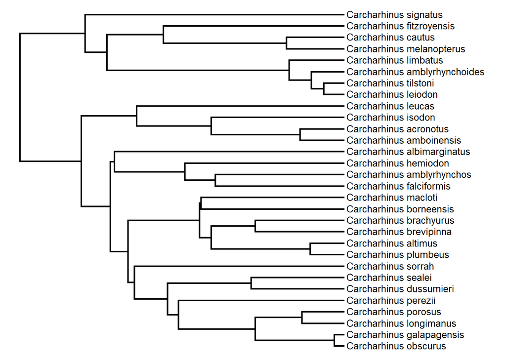

```r
# MCC tree of sharks.
tree <- readNexus(file = "Phylogeny/mcc_tree.nex")

species_tips <-
  as.data.frame(grep("Carcharhinus",tree$tip.label,value = T)) |>
  setNames(nm = "species") |>
  filter(species %in% gsub(" ","_",carcharhinus_species)) |>
  column_to_rownames(var = "species") # 30 species.

carcharhinus_tree <- treedata(phy = tree,data = species_tips, warnings = FALSE)$phy

# Carcharhinidae tree.
carcharhinidae_tree <- treedata(phy = tree,
                                data = carcharhinidae |> mutate(Species = gsub(" ","_",Species)) |> column_to_rownames(var = "Species"),
                                warnings = FALSE)$phy

# plotTree(ladderize(carcharhinidae_tree),ftype="i",lwd=1,tip.label=TRUE,fsize=.5, edge.color = "black")
plotTree(ladderize(carcharhinus_tree),fsize = .8)
```

```r
# Fully Resolved Trees (Stein et al. 2018).
# fully_resolved_tree <- readNexus(file = "Phylogeny/10.cal.tree.nex")

# The calibrated tree (Marion et al. )
# marion_et_al_2024 <- readNexus(file = "Phylogeny/16FC_16C_374_sp.tree")
# marion_et_al_2024$tip.label[69]  <- "Carcharhinus_perezii"
# marion_et_al_2024_pruned <- treedata(phy = marion_et_al_2024,data = species_tips, warnings = FALSE)$phy # 27 Carcharhinus species.
```

## Diets and niche breadth

Diets for *Carcharhinus leiodon*, *Carcharhinus hemiodon* and *Carcharhinus borneensis* were not included in the dataset by (Cortes 1999).

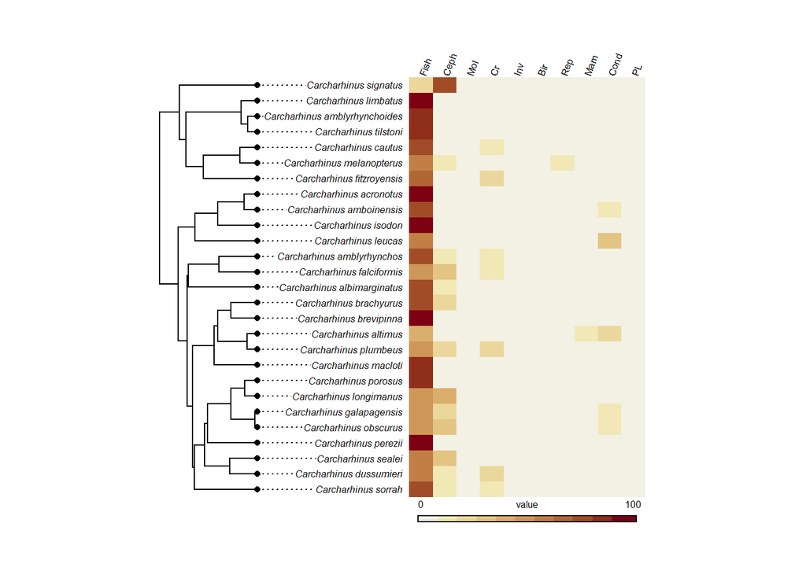

```r
# Diets.
Diets <- read.xlsx(xlsxFile = "Diets.xlsx")
rownames(Diets) <- paste(Diets$Genus,Diets$Species,sep = "_")

Diets$IUCN_2024 <- factor(Diets$IUCN_2024, levels = c("CR","EN","VU","NT","LC"))

# Subset tree.
tree_diets <- geiger::treedata(phy = carcharhinus_tree,data = Diets, warnings = FALSE)$phy # 27 species with diet and tree availability.

# Plot.
graphics::layout(matrix(1:1,nrow = 1),respect = T)

phylo.heatmap(tree = tree_diets, X = Diets[,6:15], standardize = F,
              colors = rev(sequential_hcl(11,palette = "Red-Yellow")),split=c(0.6,0.4),
              fsize = .5) # Overwhelming fish-eaters across the board.
```

```r
# Compositional diets.
closed_diets <- clo(X = Diets[,6:15])

# Convert to binary matrix.
binary_niche <-
  Diets |>
  select(6:15) |>
  mutate(across(everything(), ~ ./100)) |>
  mutate_all(~ ifelse(. == 0.0000000000, 0, 1))
```

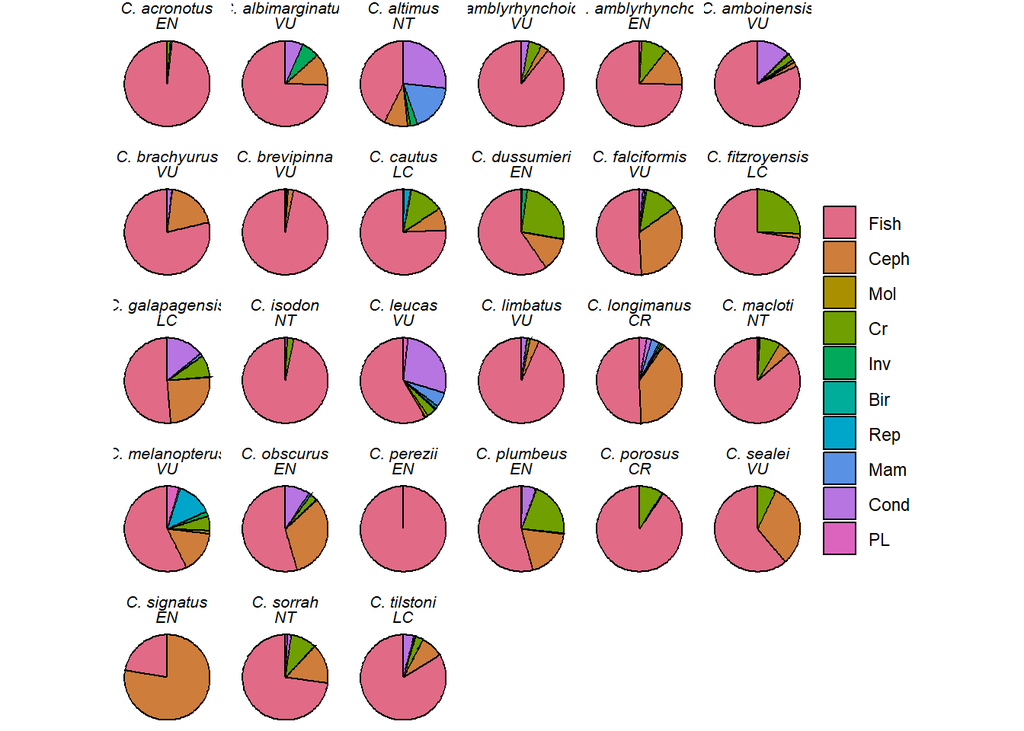

```r
# Ordinated diet breadth (ODB) analysis.
odb <- ordi.breadth(dat = binary_niche,dist.method = "jaccard")

# par(mfrow = c(6,5))
# for(i in 1:27) {
#   dist.group.plot(specialization = odb,id = i,cex = 1,verbose = F)
# }

# Data frame.
odb_results <-
  data.frame(Axis = odb$tot.breadth, Index = 1:27,
             Species = odb$species,
             Genera = gsub("_.+$","", odb$species)
             )

odb_results <-
  odb_results |>
  left_join(Traits |> mutate(Species = as.factor(paste(Genus,Species, sep = "_"))) |>
              select(Species,IUCN,Habitat,Secondary_Habitat,Size_Subclass,Ecomorphotype,Sorensen_habitat), by = "Species"
            ) # 27 species.

odb_results <-
  odb_results |>
  as.data.frame() |>
  mutate(IUCN = factor(IUCN, levels = c("CR","EN","VU","NT","LC"))) |>
  mutate(Size_Subclass = factor(Size_Subclass, levels = c("small_shark","medium_shark","large_shark")))

# IUCN colours.
iucn_categories <- factor(setNames(Diets$IUCN_2024, paste(Diets$Genus,Diets$Species, sep = "_")))
iucn_cols <- setNames(c("#B71234","#E98300","#FDC82F","#A0A831","#4CAF50"),
                      levels(iucn_categories))

# Plot.
p1 <-
  odb_results |>
  mutate(abbreviated_species = Species) |>
  mutate(abbreviated_species = gsub("Carcharhinus_","C. ",abbreviated_species)) |>
  ggplot(mapping = aes(x = Index, y = Axis, size = Size_Subclass,colour = IUCN, shape = Sorensen_habitat)) +
  geom_point() +
  scale_fill_manual(values  = c("#B71234","#E98300","#FDC82F","#A0A831","#4CAF50")) +
  scale_color_manual(values = c("#B71234","#E98300","#FDC82F","#A0A831","#4CAF50")) +
  scale_x_continuous(limits = c(0,30)) +
  labs(x = "Species", y = "Total diet breadth", colour = "IUCN", size = "Body size class",shape = "Habitat") +
  # Quantiles.
  geom_hline(yintercept = c(quantile(odb_results$Axis, c(0.33, 0.66))),
           linetype = "dashed",linewidth = 1, color = "grey50") +
  annotate("text", x = 0.5, y = quantile(odb_results$Axis, 0.15),
         label = "Specialist", hjust = 0) +
  annotate("text", x = 0.5, y = quantile(odb_results$Axis, 0.85),
         label = "Generalist", hjust = 0) +
  theme_bw() +
  theme(axis.title = element_text(face = "bold"),
         legend.position = "right",
         aspect.ratio = 1)

# p1 |> print()

# Raw diets.
p2 <-
  Diets |>
  select(6:15,21) |>
  as.data.frame() |>
  rownames_to_column(var = "taxa") |>
  mutate(taxa = gsub("_"," ", taxa),
         taxa = gsub("Carcharhinus","C.", taxa)) |>
  melt() |>
  ggplot(aes(x= "", y=value, fill=variable)) +
  geom_bar(stat="identity", width=.01, color="black") +
  scale_fill_manual(values = colorspace::qualitative_hcl(n = 10,palette = "Dark 3")) +
  labs(fill = NULL) +
  coord_polar("y", start=0) +
  theme_void() +
  facet_wrap(.~taxa + IUCN_2024 ) +
  theme(plot.title = element_text(size = 8),
        strip.text = element_text(size = 8,face = "italic"))

p2 |> print()
```

## Procrustes superimposition

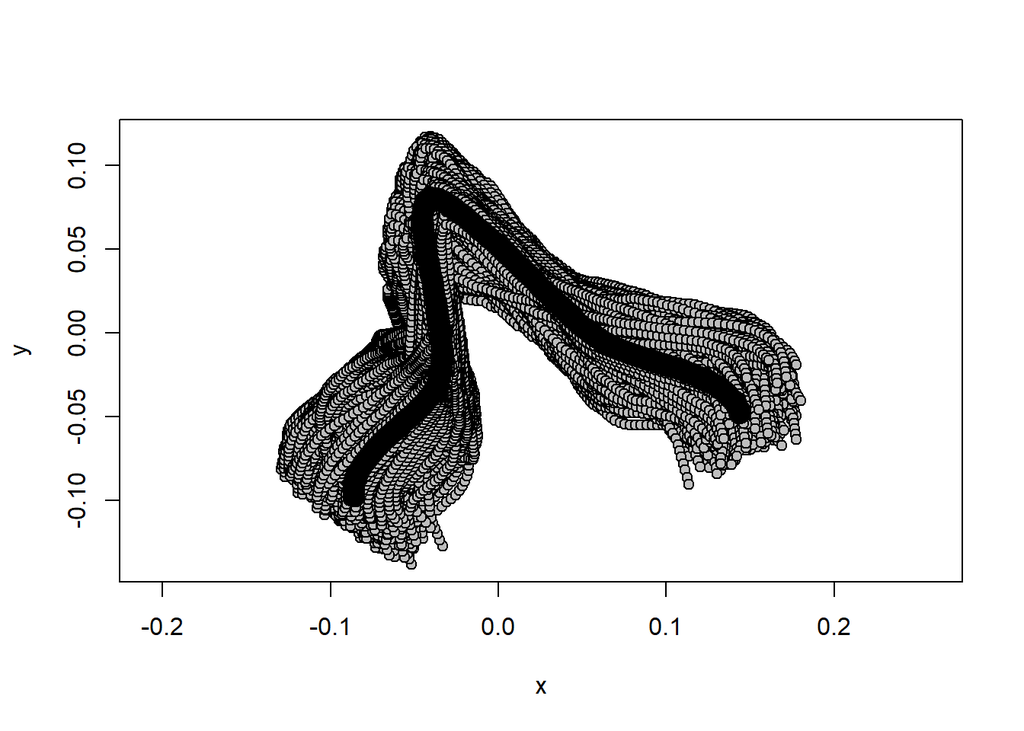

```r
# Slider file.
slider_file <-
  rbind(define.sliders(c(1,2:79,80)),
        define.sliders(c(80,81:159,160))
        )

# Procrustes superimposition.
tooth_gpa <- gpagen(A = LMs[,,rownames(Data)],curves = slider_file,
                    approxBE = T,
                    Proj = T,
                    print.progress = F,PrinAxes = T) # Without C. wheeleri.

plot(tooth_gpa)
```

```r
centroid_size <- tooth_gpa$Csize

# tooth_gpa$coords |> dim() # 1256 specimens.
```

**A general overview of the analyzed morphometric data is highlighted here.**

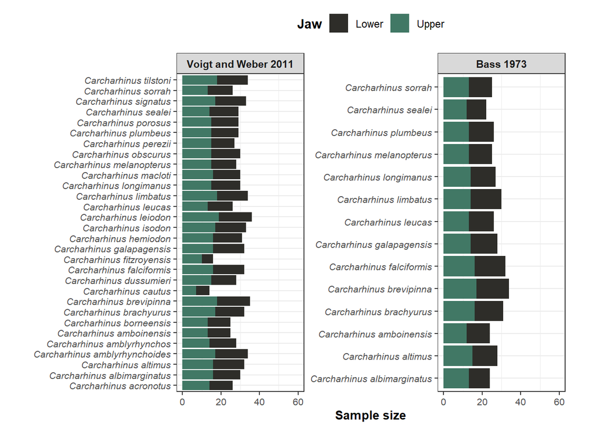

```r
# Sample size per species.
p3 <-
  dimnames(tooth_gpa$coords)[[3]] |>
  as.data.frame() |>
  setNames(nm = "Species") |>
  mutate(Source = NULL,
         Source = as.factor(c(rep("Voigt and Weber 2011",874), rep("Bass 1973",382)))) |>
  mutate(Source = relevel(x = Source,ref = 2)) |>
  mutate(Species = gsub("-"," ",Species)) |>
  mutate(Species = gsub("_.*","",Species)) |>
  group_by(Species, Source) |>
  count() |>
  ggplot(mapping = aes(x = Species, y = n)) +
  geom_col(fill = "#2E2D29") +
  labs(x = NULL, y = "Sample size") +
  coord_flip() +
  facet_wrap(.~Source,scales = "free",ncol = 1) +
  theme_bw() +
  theme(aspect.ratio = 1,
        axis.text = element_text(size = 8),
        axis.text.y = element_text(face = "italic"),
        strip.text = element_text(face = "bold"),
        axis.title = element_text(face = "bold",size = 10))

# p3 |> print()

# Size.
names(tooth_gpa$Csize) <- gsub(pattern = "_.*",replacement = "",x = names(tooth_gpa$Csize))

# Upper versus Lower teeth.
p4 <-
  Data |>
  mutate(Source = as.factor(Source)) |>
  mutate(Source = relevel(x = Source,ref = 2)) |>
  group_by(Species,Jaw, Source) |>
  count() |>
  ggplot(mapping = aes(x = Species,y = n, fill = Jaw)) +
  geom_bar(stat = "identity") +
  scale_y_continuous(limits = c(0,60)) +
  scale_fill_manual(values =   c("#2E2D29","#417865")) +
  coord_flip() +
  labs(x = NULL, y = "Sample size") +
  facet_wrap(.~Source, scales = "free",ncol = 2) +
  theme_bw() +
  theme(panel.grid.major.x = element_blank(),
        axis.text.x = element_text(size = 8),
        axis.text.y = element_text(size = 8, face = "italic"),
        axis.title = element_text(face = "bold",size = 10),
        legend.position = "top",
        legend.title = element_text(face = "bold"),
        strip.text = element_text(face = "bold"),
        plot.title = element_text(face = "bold"),
        aspect.ratio = 2.5)

p4 |> print()
```

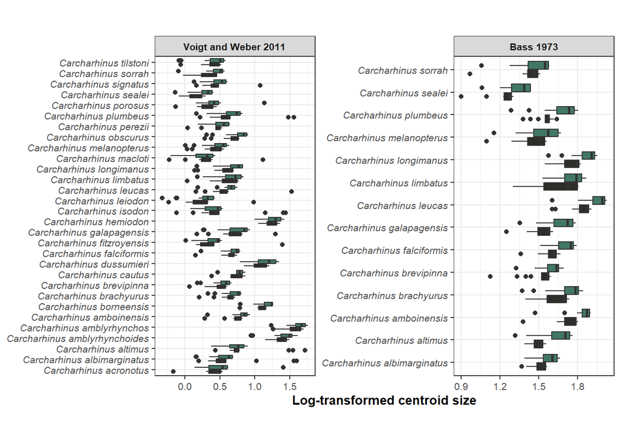

```r
species_sample <-
  data.frame(species = names(tooth_gpa$Csize),
             cz = as.vector(log10(tooth_gpa$Csize)),
             Source = as.factor(c(rep("Voigt and Weber 2011",874), rep("Bass 1973",382)))) |>
  group_by(species,Source) |>
  count() |>
  mutate(LA = paste(species,"n=",n,sep = " ")) |>
  mutate(LA = gsub("= ","=",LA)) |>
  mutate(LA = gsub("n=","\nn=",LA)) |>
  mutate(LA = gsub("-"," ",LA))

# label_vec <- setNames(species_sample$LA, gsub("-"," ",species_sample$species))

p5 <-
  data.frame(species = gsub("-"," ",names(tooth_gpa$Csize)),
             cz = as.vector(log10(tooth_gpa$Csize)),
             jaw = gsub(".*(_[LU]).*", "\\1", names(centroid_size)),
             Source = as.factor(c(rep("Voigt and Weber 2011",874), rep("Bass 1973",382)))) |>
  mutate(Source = relevel(x = Source,ref = 2)) |>
  mutate(jaw = gsub("_L", "Lower", jaw)) |>
  mutate(jaw = gsub("_U", "Upper", jaw)) |>
  ggplot(mapping = aes(x = cz, y = species, fill = jaw)) +
  geom_boxplot() +
  scale_fill_manual(values =    c("#2E2D29","#417865")) +
  scale_color_manual(values =   c("#2E2D29","#417865")) +
  labs(x = "Log-transformed centroid size",y = NULL, fill = "Jaw unit") +
  facet_wrap(.~Source,scales = "free") +
  theme_bw() +
  theme(axis.text.y = element_text(face = "italic"),
        axis.text = element_text(size = 8),
        axis.title = element_text(face = "bold",size = 10),
        strip.text = element_text(face = "bold"),
        legend.title = element_text(face = "bold"),
        strip.text.x = element_text(size = 8),
        legend.position = "none",
        aspect.ratio = 2)
  # scale_y_discrete(labels = label_vec)

p5 |> print()
```

## Principal components analysis

### Specimen level

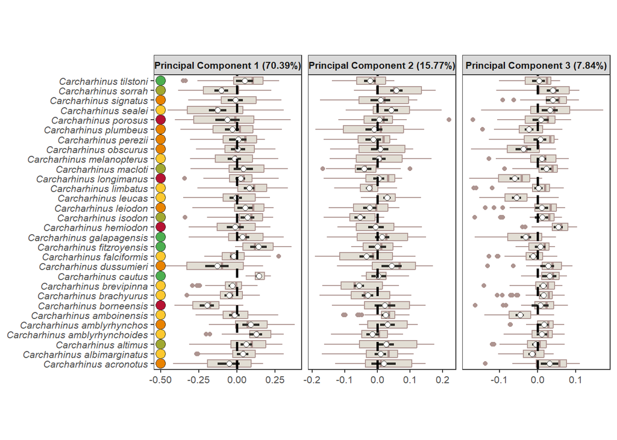

```r
# PCA
pca <- gm.prcomp(A = tooth_gpa$coords)

# Variance explained.
# round(unlist(pca$sdev^2/sum(pca$sdev^2))[1:4],digits = 4) * 100 # PC1 = 70.39%, PC2 = 15.77%, PC3 = 7.84%, PC4 = 1.59%

pca_data <-
  data.frame(PC1 = pca$x[,1],
             PC2 = pca$x[,2],
             PC3 = pca$x[,3],
             Species = gsub("-"," ", x = gsub("_.*","",x = rownames(pca$x))),
             Jaw = gsub("_L","Lower",gsub("_U","Upper", gsub(".*(_L|_U).*", "\\1", rownames(pca$x)))),
             Serrations = setNames(Data$Serration,rownames(Data)),
             cz = as.numeric(unname(tooth_gpa$Csize))
             ) |>
  left_join(Traits |>
              mutate(Species = paste(Genus,Species,sep = " ")) |>
              select(Species, IUCN, Habitat,Secondary_Habitat,Size_Subclass,Ecomorphotype,Sorensen_habitat),by = "Species") |>
  mutate(IUCN = factor(IUCN, levels = c("CR","EN","VU","NT","LC"))) |>
  # Adjust serration factor.
  mutate(Serrations = stringr::str_squish(Serrations))

rownames(pca_data) <- rownames(pca$x)

# Species-averages.
average_species <-
  pca_data |>
  group_by(Species) |>
  summarise(PC1 = mean(PC1),PC2 = mean(PC2),PC3 = mean(PC3)) |>
  pivot_longer(cols = c(2:4),names_to = "variable")

# Species
specimen_axes <-
  pca_data |>
  pivot_longer(cols = c(1:3),names_to = "variable")

# Plot specimen level PCA.
specimen_axes |>
  ggplot(mapping = aes(x = Species, y = value, colour = Species)) +
  geom_boxplot(colour = "#AD9490", fill = "#E2DED4",show.legend = F) +
  stat_summary(fun.data = mean_cl_boot, geom = "errorbar",width = .0, lwd = 1, linetype = 1, col = "#2E2D29") +
  geom_point(mapping = aes(x = Species, y = value),data = average_species,size = 2,show.legend = F,
             fill = "#FFFFFF", colour = "#2E2D29", shape = 21) +
  geom_hline(yintercept = 0.0,linewidth = 1,linetype = 2,colour = "black") +
  coord_flip() +
  # Add IUCN status.
  geom_point(data = specimen_axes |> filter(variable == "PC1") |> distinct(Species,IUCN,variable),
             aes(y = -0.5, x = Species, fill = IUCN),
             inherit.aes = FALSE,
             shape = 21, colour = "#2E2D29", size = 3.5,
             show.legend = F) +
  # Custom colors.
  scale_fill_manual(values  = c("#B71234","#E98300","#FDC82F","#A0A831","#4CAF50")) +
  facet_wrap(.~variable, scales = "free_x",
             labeller = labeller(variable = c(
               PC1 = "Principal Component 1 (70.39%)",
               PC2 = "Principal Component 2 (15.77%)",
               PC3 = "Principal Component 3 (7.84%)"))) +
  labs(x = NULL, y = NULL) +
  theme_bw() +
  theme(axis.text.y = element_text(face = "italic",size = 8),
        axis.text.x = element_text(size = 8),
        aspect.ratio = 2,
        panel.grid = element_blank(),
        strip.text = element_text(face = "bold",size = 8))
```

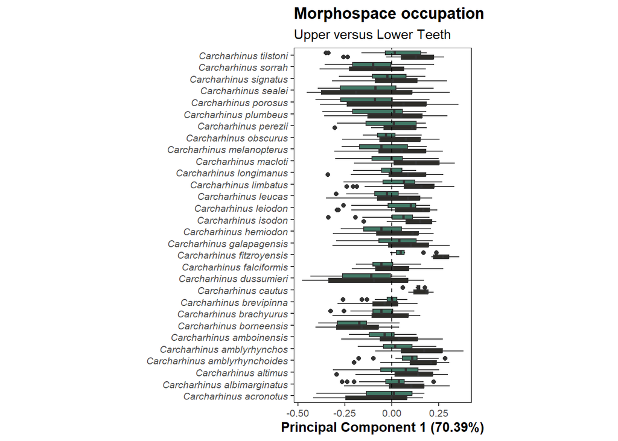

```r
# Function to compute the modal value.
estimate_mode <- function(x) {
  d <- hist(x, plot = FALSE)
  mode <- d$mids[which.max(d$counts)]
  return(mode)
}

mode_iucn <-
  pca_data |>
  group_by(IUCN) |>
  summarise(PC1 = estimate_mode(PC1),PC2 = estimate_mode(PC2))

# Plot by jaw: PC1. ANOVA tables are required for these as well.
p6 <-
  pca_data |>
  ggplot(mapping = aes(x = Species, y = PC1, fill = Jaw)) +
  geom_boxplot() +
  scale_fill_manual(values =  c("#2E2D29","#417865")) +
  scale_color_manual(values = c("#2E2D29","#417865")) +
  geom_hline(yintercept = 0.0,linetype = 2) +
  labs(y = "Principal Component 1 (70.39%)", x = NULL, title = "Morphospace occupation",subtitle = "Upper versus Lower Teeth") +
  coord_flip() +
  theme_bw() +
  theme(aspect.ratio = 2,
        panel.grid = element_blank(),
        axis.title = element_text(face = "bold"),
        legend.position = "none",
        legend.title = element_text(face = "bold"),
        plot.title = element_text(face = "bold"),
        axis.text = element_text(size = 8),
        axis.text.y = element_text(face = "italic"))

p6 |> print()
```

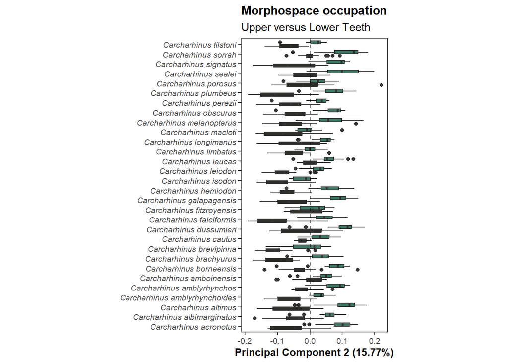

```r
# PC2.
p7 <-
  pca_data |>
  ggplot(mapping = aes(x = Species, y = PC2, fill = Jaw)) +
  geom_boxplot() +
  scale_fill_manual(values =  c("#2E2D29","#417865")) +
  scale_color_manual(values = c("#2E2D29","#417865")) +
  geom_hline(yintercept = 0.0,linetype = 2) +
  labs(y = "Principal Component 2 (15.77%)", x = NULL, title = "Morphospace occupation",subtitle = "Upper versus Lower Teeth") +
  coord_flip() +
  theme_bw() +
  theme(aspect.ratio = 2,
        panel.grid = element_blank(),
        axis.title = element_text(face = "bold",size = 10),
        legend.position = "none",
        legend.title = element_text(face = "bold"),
        plot.title = element_text(face = "bold",size = 12),
        axis.text = element_text(size = 8),
        axis.text.y = element_text(face = "italic"))

p7 |> print()
```

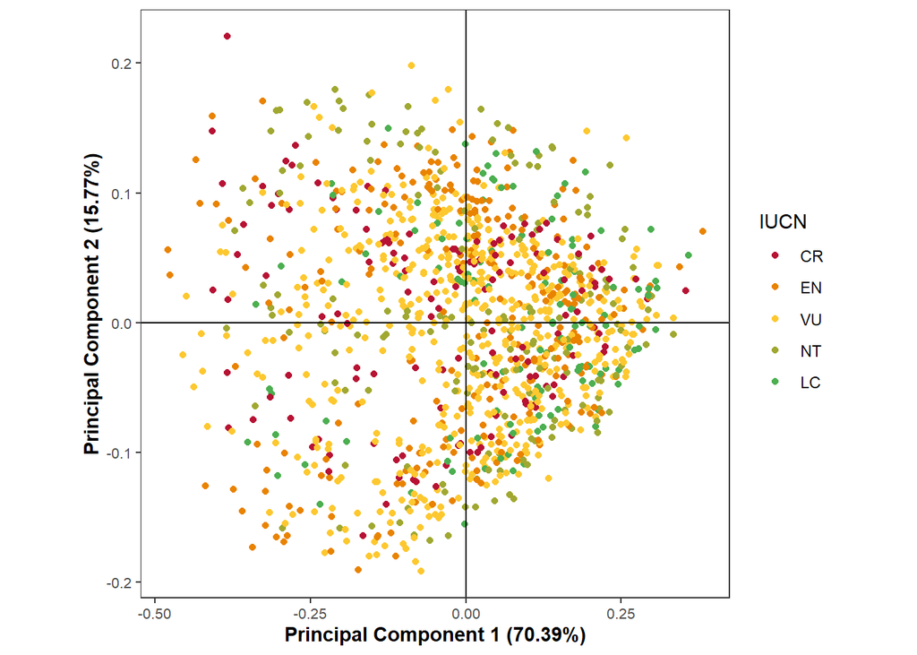

```r
# IUCN
p8 <-
  pca_data |>
  ggplot(mapping = aes(x = PC1, y = PC2, colour = IUCN)) +
  geom_point() +
  scale_fill_manual(values  = c("#B71234","#E98300","#FDC82F","#A0A831","#4CAF50")) +
  scale_color_manual(values = c("#B71234","#E98300","#FDC82F","#A0A831","#4CAF50")) +
  geom_vline(xintercept = 0) +
  geom_hline(yintercept = 0) +
  labs(x = "Principal Component 1 (70.39%)", y = "Principal Component 2 (15.77%)") +
  theme_bw() +
  theme(aspect.ratio = 1,
        panel.grid = element_blank(),
        axis.title = element_text(face = "bold"),
        axis.text = element_text(size = 8),
        legend.position = "right")

p8 |> print()
```

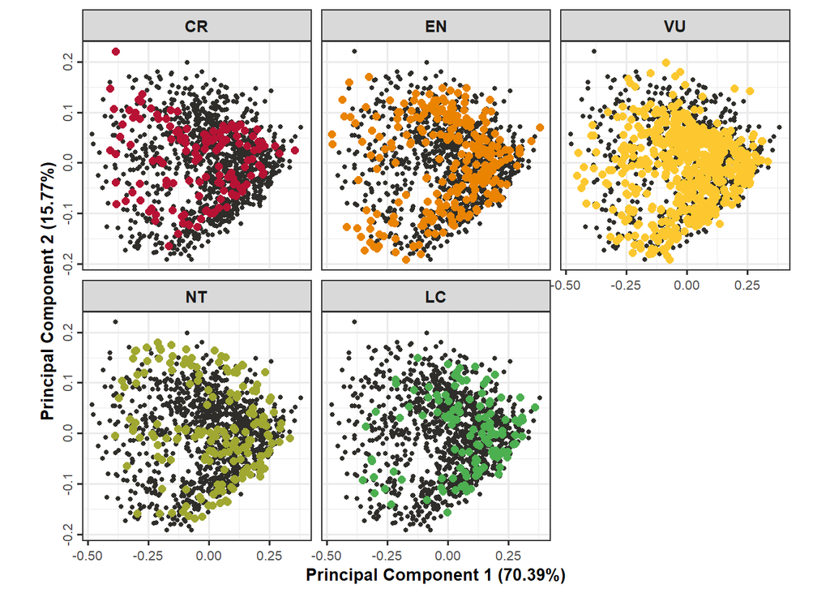

```r
highlight_data <-
  pca_data |>
  group_by(IUCN) |>
  mutate(highlight_group = IUCN) |>
  ungroup()

# Plot.
p9 <-
  ggplot() +
  geom_point(data = pca_data, aes(x = PC1, y = PC2),
             colour = "#2E2D29", size = 1) +
  geom_point(data = highlight_data,
             aes(x = PC1, y = PC2, colour = highlight_group), size = 2) +
  labs(x = "Principal Component 1 (70.39%)", y = "Principal Component 2 (15.77%)") +
  facet_wrap(~ highlight_group) +
  scale_colour_manual(values = c("#B71234","#E98300","#FDC82F","#A0A831","#4CAF50")) +
  theme_bw(base_size = 12) +
  theme(legend.position = "none",
        strip.text = element_text(face = "bold"),
        axis.text = element_text(size = 8),
        axis.text.y = element_text(angle = 90,hjust = .5,vjust = .5),
        axis.title = element_text(size = 10,face = "bold"),
        aspect.ratio = 1)

p9 |> print()
```

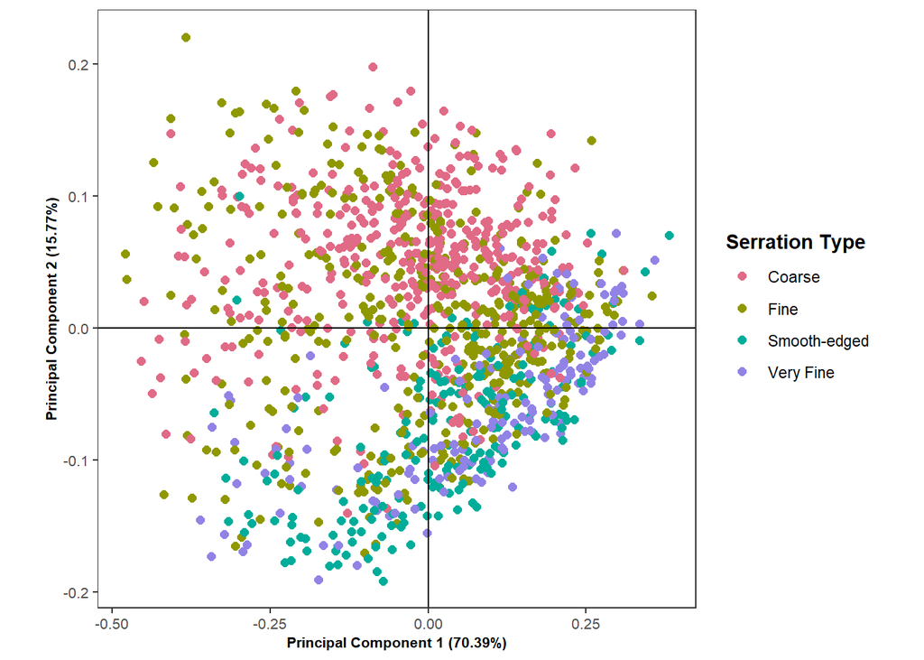

```r
# Jaws and serrations.
p10 <-
  pca_data |>
  ggplot(mapping = aes(x = PC1, y = PC2, colour = Serrations)) +
  geom_point(size = 2) +
  geom_vline(xintercept = 0) +
  geom_hline(yintercept = 0) +
  scale_fill_manual(values = qualitative_hcl(n = 4,"Dark 3")) +
  scale_colour_manual(values = qualitative_hcl(n = 4,"Dark 3")) +
  labs(x = "Principal Component 1 (70.39%)", y = "Principal Component 2 (15.77%)", colour = "Serration Type") +
  theme_bw() +
  theme(aspect.ratio = 1,
        panel.grid = element_blank(),
        legend.title = element_text(face = "bold"),
        legend.position = "right",
        axis.text = element_text(size = 8),
        axis.title = element_text(size = 8,face = "bold"))

p10 |> print()
```

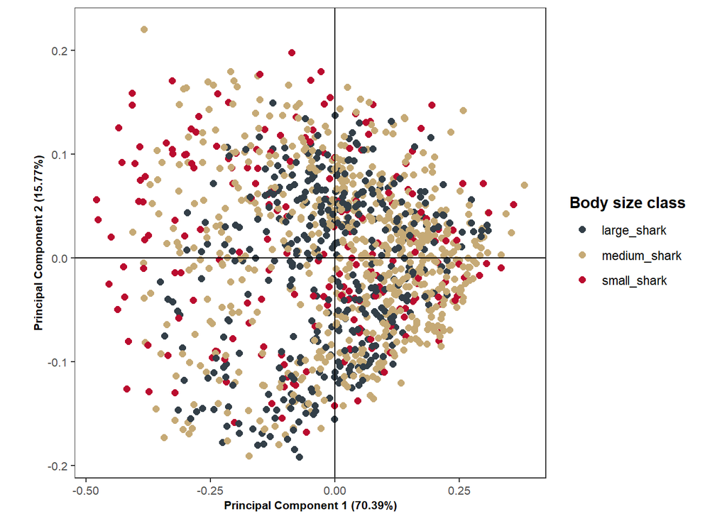

```r
# Ecomorphotypes.
p11 <-
  pca_data |>
  ggplot(mapping = aes(x = PC1, y = PC2, colour = Ecomorphotype)) +
  geom_point() +
  geom_vline(xintercept = 0) +
  geom_hline(yintercept = 0) +
  scale_fill_manual(values =   c("#7a1e47","#29505d")) +
  scale_colour_manual(values = c("#7a1e47","#29505d")) +
  labs(x = "Principal Component 1 (70.39%)", y = "Principal Component 2 (15.77%)") +
  theme_bw() +
  theme(aspect.ratio = 1,
        panel.grid = element_blank(),
        legend.title = element_text(face = "bold"),
        legend.position = "right",
        axis.text = element_text(size = 8),
        axis.title = element_text(size = 8,face = "bold"))

# p11 |> print()

average_body_class <-
  pca_data |>
  group_by(Size_Subclass) |>
  summarise(PC1 = mean(PC1),PC2 = mean(PC2),PC3 = mean(PC3))

p12 <-
  pca_data |>
  ggplot(mapping = aes(x = PC1, y = PC2, colour = Size_Subclass)) +
  geom_point(size = 2) +
  geom_vline(xintercept = 0) +
  geom_hline(yintercept = 0) +
  scale_color_manual(values = c("#333F48FF","#C6AA76FF","#BA0C2FFF")) +
  scale_fill_manual(values =  c("#333F48FF","#C6AA76FF","#BA0C2FFF")) +
  labs(x = "Principal Component 1 (70.39%)", y = "Principal Component 2 (15.77%)", colour = "Body size class") +
  theme_bw() +
  theme(aspect.ratio = 1,
        panel.grid = element_blank(),
        legend.position = "right",
        legend.title = element_text(face = "bold"),
        axis.text = element_text(size = 8),
        axis.title = element_text(size = 8,face = "bold"))

p12 |> print()
```

```r
# Main habitat.
p13 <-
  pca_data |>
  ggplot(mapping = aes(x = PC1, y = PC2, colour = Habitat)) +
  geom_point() +
  scale_fill_manual(values  = c("#007C92","#B83A4B")) +
  scale_color_manual(values = c("#007C92","#B83A4B")) +
  geom_vline(xintercept = 0) +
  geom_hline(yintercept = 0) +
  labs(x = "Principal Component 1 (70.39%)", y = "Principal Component 2 (15.77%)") +
  theme_bw() +
  theme(aspect.ratio = 1,
        panel.grid = element_blank(),
        legend.position = "right",
        legend.title = element_text(face = "bold"),
        axis.text = element_text(size = 8),
        axis.title = element_text(size = 8,face = "bold"))

# p13 |> print()

# Secondary habitat.
p14 <-
  pca_data |>
  ggplot(mapping = aes(x = PC1, y = PC2, colour = Secondary_Habitat)) +
  geom_point() +
  geom_vline(xintercept = 0) +
  geom_hline(yintercept = 0) +
  scale_colour_manual(values = c("#FFC20A", "#0C7BDC")) +
  scale_fill_manual(values =   c("#FFC20A", "#0C7BDC")) +
  labs(x = "Principal Component 1 (70.39%)", y = "Principal Component 2 (15.77%)") +
  theme_bw() +
  theme(aspect.ratio = 1,
        panel.grid = element_blank(),
        legend.position = "right",
        legend.title = element_text(face = "bold"),
        axis.text = element_text(size = 8),
        axis.title = element_text(size = 8,face = "bold"))

# p14 |> print()

# Tertiary habitat.
p15 <-
  pca_data |>
  ggplot(mapping = aes(x = PC1, y = PC2, colour = Sorensen_habitat)) +
  geom_point(size = 2) +
  geom_vline(xintercept = 0) +
  geom_hline(yintercept = 0) +
  scale_fill_manual(values =   darken(col = c("#FEE08B", "#BEDCEB", "#FFA384"),amount = .3)) +
  scale_colour_manual(values = darken(col = c("#FEE08B", "#BEDCEB", "#FFA384"),amount = .3)) +
  labs(x = "Principal Component 1 (70.39%)", y = "Principal Component 2 (15.77%)", colour = "Habitat") +
  theme_bw() +
  theme(aspect.ratio = 1,
        panel.grid = element_blank(),
        legend.position = "right",
        legend.title = element_text(face = "bold"),
        axis.text = element_text(size = 8),
        axis.title = element_text(size = 8,face = "bold"))

p16   <-
  pca_data |>
  mutate(status = case_when(IUCN %in% c("CR","EN","VU") ~ "Threatened", T ~ "Not-threatened")) |>
  ggplot(mapping = aes(x = PC1, y = PC2, colour = status)) +
  geom_point(size = 2) +
  geom_vline(xintercept = 0) +
  geom_hline(yintercept = 0) +
  labs(x = "Principal Component 1 (70.39%)", y = "Principal Component 2 (15.77%)", colour = "Habitat") +
  theme_bw() +
  theme(aspect.ratio = 1,
        panel.grid = element_blank(),
        legend.position = "right",
        legend.title = element_text(face = "bold"),
        axis.text = element_text(size = 8),
        axis.title = element_text(size = 8,face = "bold"))

# p16 |> print()
```

### Species level analysis

Are smaller, medium or larger species at more risk of extinction? Are threatened species living in extreme areas of morphospace?

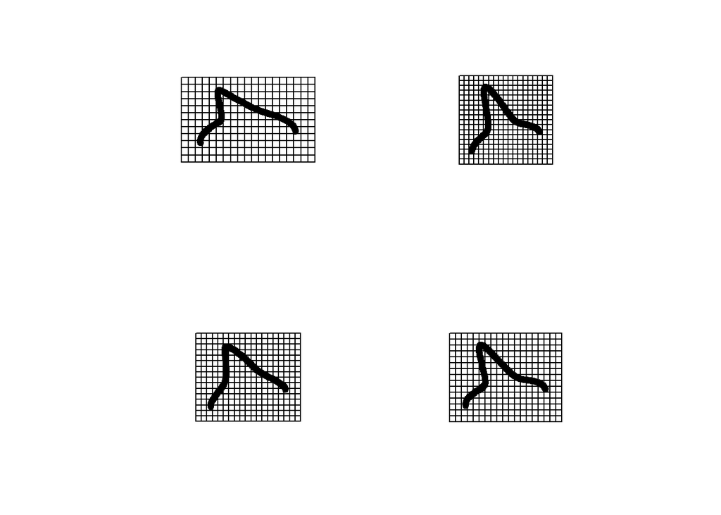

```r
species_coords <- tooth_gpa$coords

dimnames(species_coords)[[3]] <- gsub("-"," ",dimnames(species_coords)[[3]])
dimnames(species_coords)[[3]] <- gsub("_.*", "",dimnames(species_coords)[[3]])
dimnames(species_coords)[[3]] <- gsub(" ", "_",dimnames(species_coords)[[3]])

# Computing an average shape.
species_subset <- coords.subset(A = species_coords, group = as.factor(dimnames(species_coords)[[3]]))

species_subset <-
  lapply(species_subset, mshape) |>
  simplify2array()

# Shape analysis via PCA.
average_pca <- gm.prcomp(A = species_subset,phy = carcharhinus_tree)

# Variance explained.
# barplot(round(unlist(average_pca$sdev^2/sum(average_pca$sdev^2)),4)* 100,las = 2,horiz = F,ylab = "Variance Explained")
# dev.off()

# Plot tps grids.
layout(matrix(1:4,nrow = 2,byrow = T),respect = T)

plotRefToTarget(average_pca$shapes$shapes.comp1$min,average_pca$shapes$shapes.comp1$min)
plotRefToTarget(average_pca$shapes$shapes.comp1$max,average_pca$shapes$shapes.comp1$max)
plotRefToTarget(average_pca$shapes$shapes.comp2$min,average_pca$shapes$shapes.comp2$min)
plotRefToTarget(average_pca$shapes$shapes.comp2$max,average_pca$shapes$shapes.comp2$max)
```

```r
dev.off()
```

```r
par(mfrow = c(1,2))
plotRefToTarget(average_pca$shapes$shapes.comp3$min,average_pca$shapes$shapes.comp3$min) # Less telling
plotRefToTarget(average_pca$shapes$shapes.comp3$max,average_pca$shapes$shapes.comp3$max) # Less telling
dev.off()
```

```r
# IUCN colours for all species and not only those with diets.
iucn_species <- factor(setNames(Traits$IUCN, paste(Traits$Genus,Traits$Species, sep = "_")),
                       levels = c("CR","EN","VU","NT","LC")) # 30 taxa.
iucn_colours <- setNames(c("#B71234","#E98300","#FDC82F","#A0A831","#4CAF50"),
                      levels(iucn_species))
# Ecomorphology.
ecomorph_species <- factor(setNames(Traits$Ecomorphotype, paste(Traits$Genus,Traits$Species, sep = "_")))
ecomorph_colours <- setNames(c("#544948","#417865"),levels(ecomorph_species))

# Main Habitats.
habitat_species <- factor(setNames(Traits$Habitat, paste(Traits$Genus,Traits$Species, sep = "_")))
habitat_colours <- setNames(c("#766253","#016895"),levels(habitat_species))

# Secondary habitat.
secondary_habitat_species <- factor(setNames(Traits$Secondary_Habitat, paste(Traits$Genus,Traits$Species, sep = "_")))
secondary_colours <- setNames(c("#EDE8D0","black"),levels(secondary_habitat_species))

# Tertiary habitat.
sorenson_habitats <- factor(setNames(Traits$Sorensen_habitat, paste(Traits$Genus,Traits$Species, sep = "_")))

# Body size class
size_species <- factor(setNames(Traits$Size_Subclass, paste(Traits$Genus,Traits$Species, sep = "_")))
size_colours <- setNames(c("#2D716F","#766253","#A6B168"),levels(size_species))

# Serrations.
serration_type <-
  Data |>
  select(Species,Serration) |>
  distinct(Species,.keep_all = T) |>
  mutate(Species = gsub(" ","_",Species)) |>
  mutate(Serration = stringr::str_squish(Serration)) |>
  as_tibble()

# Phylomorphospace plot.
layout(matrix(c(1:1)),respect = T)
plot(average_pca, axis1 = 1, axis2 = 2,phylo = TRUE, main = NULL,
     cex = setNames(c(3.5,2.5,1.5),levels(size_species))[size_species[rownames(average_pca$x)]],
     pch = 21,asp = 2,col = "#2E2D29",
     bg = iucn_colours[iucn_species[rownames(average_pca$x)]],font.lab = 2,cex.axis = .7,cex.lab = .7,
     phylo.par= list(tip.labels = T, node.labels=FALSE, edge.color= "#2E2D29",
                     edge.width= 1, tip.txt.cex =0.5,
                     tip.txt.adj = c(-0.1, -0.1))
     );minor.tick(nx = 2, ny = 2, tick.ratio = 0.5) # IUCN, body size and habitat.

# Legends.
legend("topleft",legend = names(iucn_colours),col = unname(iucn_colours),pch = 19,cex = .5,bty = "n")
# Second legend.
legend("topright",legend = names(size_colours)[c(3,2,1)],col = "black",pch = 21,
       pt.cex = c(1.5,2.5,3.5),
       bty = "n")

# Use "|" for reef asscoiated, "-" for shelf-associated and + for coastal pelagic.
pch_overlay <-
  ifelse(sorenson_habitats == "Reef", "|",
       ifelse(sorenson_habitats == "Shelf", "-",
              ifelse(sorenson_habitats == "Coastal pelagic", "+", NA)))

habitat_symbol <- factor(setNames(object = pch_overlay, paste(Traits$Genus,Traits$Species, sep = "_")))

par(new = T)
points(average_pca$x[,1:2], pch = as.vector(unname(habitat_symbol[rownames(average_pca$x)])), col = "black", cex = 1.5)
#points(average_pca$x[,c(1,3)], pch = as.vector(unname(habitat_symbol[rownames(average_pca$x)])), col = "black", cex = 1.5)

# Boxplots.
layout(matrix(c(1:2),nrow = 1,ncol = 2),widths = c(4,4),heights = c(7,7),respect = T)
boxplot(average_pca$x[,1] ~ iucn_species[rownames(average_pca$x)],col = "white",border = "black",
        frame.plot=F,boxwex=.8,staplewex=.5,boxlwd=2,medlwd=2,
        ylab = expression(bold("PC1 (78.77%)")),
        xlab = expression(bold("IUCN status")),outcol = scales::alpha("black",.5), outpch = 19,
        notch = FALSE,xaxt="n");abline(h = mean(average_pca$x[,1]),lwd = 2, col = "black", lty = 2)

boxplot(average_pca$x[,2] ~ iucn_species[rownames(average_pca$x)],col = "white",border = "black",
        frame.plot=F,boxwex=.8,staplewex=.5,boxlwd=2,medlwd=2,
        ylab = expression(bold("PC2 (9.31%)")),
        xlab = expression(bold("IUCN status")),outcol = scales::alpha("black",.5), outpch = 19,
        notch = FALSE,xaxt="n");abline(h = mean(average_pca$x[,2]),lwd = 2, col = "black", lty = 2)

# Add text labels for groups on x-axis.
axis(1, at = 1:5, labels = FALSE, tck = -0.02)
text(x = 1:5, y = par()$usr[3] - 0.025*(par()$usr[4] - par()$usr[3]),
     labels = names(iucn_colours), srt = 45, adj = 1, xpd = TRUE)
```

#### Linear models

Here we ask if species differ in shape. The results show that shape differences are indeed influenced by species, tooth-type, and size. Among these, dignathic heterodonty is the strongest covariate after species identity.

```r
# Do species occupy different areas of morphospace?
specimen_coords <- tooth_gpa$coords
dimnames(specimen_coords)[[3]] <- gsub(" ", "-",x = gsub("_.*","", x = gsub("-"," ", dimnames(specimen_coords)[[3]])))

# Define data frame.
specimen_iucn <-
  as.data.frame(dimnames(specimen_coords)[[3]]) |>
  setNames(nm = "Species") |>
  left_join(Traits |> select(Genus,Species,IUCN) |> mutate(Species = paste0(Genus,"-",Species)),by = "Species") |>
  select(-2) |>
  pull(IUCN)

gdf_specimens <-
  geomorph.data.frame(coords = specimen_coords,
                      Csize = tooth_gpa$Csize,
                      species = as.factor(gsub(" ", "-",x = gsub("_.*","", x = gsub("-"," ", dimnames(tooth_gpa$coords)[[3]])))),
                      dignathic_heterodonty = as.factor(gsub(".*_([LU])[0-9]+\\.png$", "\\1",dimnames(tooth_gpa$coords)[[3]])),
                      iucn = specimen_iucn
                      )

# Fit linear models.
fit_01 <- procD.lm(coords ~ log(Csize) + species, data = gdf_specimens,
                   print.progress = FALSE,RRPP = T,
                   iter = 999,seed = 1) # parallel slopes.

fit_02 <- procD.lm(coords ~ log(Csize) * species, data = gdf_specimens,
                   print.progress = FALSE,RRPP = T,
                   iter = 999,seed = 1) # different slopes (species-specific allometries)

fit_03 <- procD.lm(coords ~ log(Csize) * species + dignathic_heterodonty, data = gdf_specimens,
                    print.progress = FALSE,RRPP = T,
                    iter = 999,seed = 1)

anova(fit_01)
```

```
Analysis of Variance, using Residual Randomization
Permutation procedure: Randomization of null model residuals
Number of permutations: 1000
Estimation method: Ordinary Least Squares
Sums of Squares and Cross-products: Type I
Effect sizes (Z) based on F distributions

             Df     SS       MS     Rsq      F       Z Pr(>F)
log(Csize)    1  0.242 0.242342 0.00490 7.3207  2.7349  0.001 ***
species      29  8.649 0.298242 0.17493 9.0093 10.7411  0.001 ***
Residuals  1225 40.552 0.033104 0.82017
Total      1255 49.443
---
Signif. codes:  0 '***' 0.001 '**' 0.01 '*' 0.05 '.' 0.1 ' ' 1

Call: procD.lm(f1 = coords ~ log(Csize) + species, iter = 999, seed = 1,
    RRPP = T, data = gdf_specimens, print.progress = FALSE)
```

```r
anova(fit_02)
```

```
Analysis of Variance, using Residual Randomization
Permutation procedure: Randomization of null model residuals
Number of permutations: 1000
Estimation method: Ordinary Least Squares
Sums of Squares and Cross-products: Type I
Effect sizes (Z) based on F distributions

                     Df     SS       MS     Rsq      F       Z Pr(>F)
log(Csize)            1  0.242 0.242342 0.00490 7.4954  2.7638  0.001 ***
species              29  8.649 0.298242 0.17493 9.2244 10.7882  0.001 ***
log(Csize):species   29  1.883 0.064929 0.03808 2.0082  3.7971  0.001 ***
Residuals          1196 38.669 0.032332 0.78209
Total              1255 49.443
---
Signif. codes:  0 '***' 0.001 '**' 0.01 '*' 0.05 '.' 0.1 ' ' 1

Call: procD.lm(f1 = coords ~ log(Csize) * species, iter = 999, seed = 1,
    RRPP = T, data = gdf_specimens, print.progress = FALSE)
```

```r
anova(fit_03) # This is the better model. Confirms that species are indeed different despite extensive overlap.
```

```
Analysis of Variance, using Residual Randomization
Permutation procedure: Randomization of null model residuals
Number of permutations: 1000
Estimation method: Ordinary Least Squares
Sums of Squares and Cross-products: Type I
Effect sizes (Z) based on F distributions

                        Df     SS     MS     Rsq        F       Z Pr(>F)
log(Csize)               1  0.242 0.2423 0.00490   8.4582  2.9138  0.001 ***
species                 29  8.649 0.2982 0.17493  10.4092 11.2770  0.001 ***
dignathic_heterodonty    1  4.415 4.4147 0.08929 154.0815  6.1504  0.001 ***
log(Csize):species      29  1.898 0.0655 0.03840   2.2849  4.4224  0.001 ***
Residuals             1195 34.239 0.0287 0.69249
Total                 1255 49.443
---
Signif. codes:  0 '***' 0.001 '**' 0.01 '*' 0.05 '.' 0.1 ' ' 1

Call: procD.lm(f1 = coords ~ log(Csize) * species + dignathic_heterodonty,
    iter = 999, seed = 1, RRPP = T, data = gdf_specimens, print.progress = FALSE)
```

```r
# Are the IUCN categories different?
fit_04 <- procD.lm(coords ~ iucn, data = gdf_specimens,
                   print.progress = FALSE,RRPP = T, iter = 999,seed = 1)

anova(fit_04) # Yes.
```

```
Analysis of Variance, using Residual Randomization
Permutation procedure: Randomization of null model residuals
Number of permutations: 1000
Estimation method: Ordinary Least Squares
Sums of Squares and Cross-products: Type I
Effect sizes (Z) based on F distributions

            Df     SS       MS     Rsq      F      Z Pr(>F)
iucn         4  1.077 0.269268 0.02178 6.9646 4.7913  0.001 ***
Residuals 1251 48.366 0.038662 0.97822
Total     1255 49.443
---
Signif. codes:  0 '***' 0.001 '**' 0.01 '*' 0.05 '.' 0.1 ' ' 1

Call: procD.lm(f1 = coords ~ iucn, iter = 999, seed = 1, RRPP = T,
    data = gdf_specimens, print.progress = FALSE)
```

```r
# Pairwise test,
summary(pairwise(fit = fit_04, groups = interaction(gdf_specimens$iucn)))
```

```
Pairwise comparisons

Groups: CR EN LC NT VU

RRPP: 1000 permutations

LS means:
Vectors hidden (use show.vectors = TRUE to view)

Pairwise distances between means, plus statistics
               d  UCL (95%)         Z Pr > d
CR:EN 0.03801174 0.03698908 1.7248952  0.041
CR:LC 0.10814662 0.04285445 4.1033295  0.001
CR:NT 0.05945970 0.03843924 2.6391878  0.001
CR:VU 0.04099686 0.03266913 2.1161040  0.011
EN:LC 0.07708016 0.03857411 3.1684607  0.001
EN:NT 0.02426113 0.03320583 0.9065917  0.186
EN:VU 0.02374796 0.02595218 1.4711916  0.075
LC:NT 0.06210798 0.03798930 2.7922582  0.003
LC:VU 0.07436891 0.03513685 3.5372371  0.001
NT:VU 0.03355929 0.02929403 1.9199583  0.025
```

```r
# Prepare centroid size.
average_centroid <- centroid_size
names(average_centroid) <- gsub("_.*","",names(average_centroid))

avg_cz <-
  data.frame(species = names(average_centroid),
             centroid = unname(average_centroid)
  )

ave_cz_transformed <-
  aggregate(avg_cz$centroid,list(avg_cz$species),mean) |>
  mutate(x = log10(x))

# Create new threat-status factor.
new_threat <-
  iucn_species[rownames(average_pca$x)] |>
  as.data.frame() |>
  setNames(nm = "iucn") |>
  rownames_to_column(var = "Species") |>
  mutate(threat = case_when(iucn %in% c("CR","EN","VU") ~ "Threatened", T ~ "Not"))

# Fit models.
iucn_dataframe <-
  geomorph.data.frame(coords = species_subset,
                      size = unname(setNames(ave_cz_transformed$x,ave_cz_transformed$Group.1)),
                      iucn = as.factor(unname(iucn_species[rownames(average_pca$x)])),
                      # Axes,
                      pc1 = average_pca$x[,1],
                      pc2 = average_pca$x[,2],
                      # Simplified threat status.
                      status = as.factor(new_threat$threat),
                      habitat = as.factor(unname(sorenson_habitats[rownames(average_pca$x)])),
                      body = as.factor(unname(size_species[rownames(average_pca$x)])),
                      tree = carcharhinus_tree
                      )
# Model fits.
fit_05 <- procD.lm(f1 = coords ~ 1,RRPP = T,data = iucn_dataframe, iter = 999)    # Baseline null model.
fit_06 <- procD.lm(f1 = coords ~ iucn,RRPP = T,data = iucn_dataframe, iter = 999) # Ecological divergence, not accounting for allometry.

anova(fit_05,fit_06)
anova(fit_05)

# Axis-specific.
fit_07 <- procD.lm(pc1 ~ iucn,RRPP = T,data = iucn_dataframe, iter = 999)
anova(fit_07)

# Pairwise Comparisons.
PW <- pairwise(fit_06, groups = interaction(iucn_dataframe$iucn))
summary(PW)
# Threatened versus not-treatened.
fit_08 <- procD.lm(coords ~ status,RRPP = T,data = iucn_dataframe, iter = 999)
anova(fit_08)
```

### Erosion of morphospace

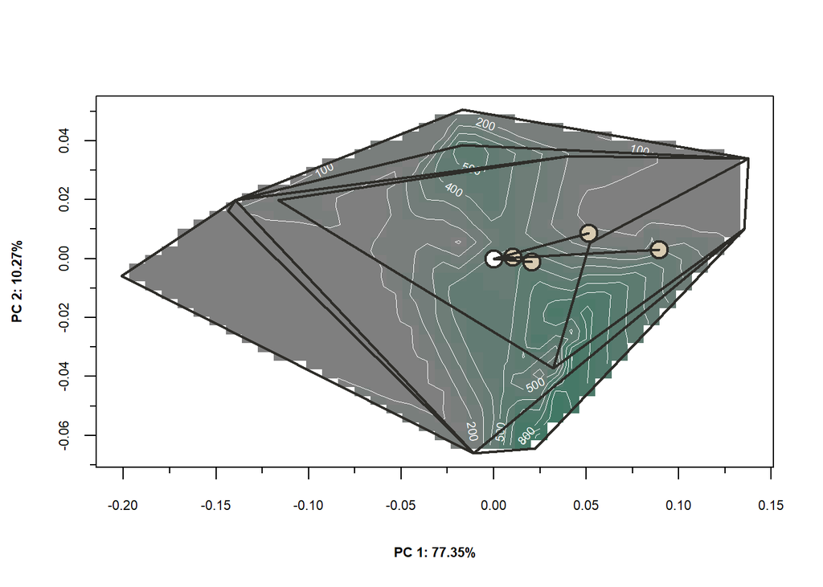

```r
# CR species.
cr <- c("Carcharhinus_borneensis","Carcharhinus_hemiodon","Carcharhinus_longimanus","Carcharhinus_porosus")

# Endangered species.
en <- c("Carcharhinus_acronotus","Carcharhinus_amblyrhynchos","Carcharhinus_dussumieri",
        "Carcharhinus_leiodon","Carcharhinus_obscurus","Carcharhinus_perezii",
        "Carcharhinus_plumbeus","Carcharhinus_signatus")

# Vulnerable species.
vu <- c("Carcharhinus_albimarginatus","Carcharhinus_amblyrhynchoides","Carcharhinus_amboinensis",
        "Carcharhinus_brachyurus","Carcharhinus_brevipinna","Carcharhinus_falciformis",
        "Carcharhinus_leucas","Carcharhinus_limbatus",
        "Carcharhinus_melanopterus","Carcharhinus_sealei")

# Near threatened species.
nt <- c("Carcharhinus_altimus","Carcharhinus_isodon","Carcharhinus_macloti","Carcharhinus_sorrah")

# Additive extinction effects.
crEn <- c(cr,en)
crEnVu <- c(cr,en,vu)
crEnVunT <- c(cr,en,vu,nt) # This leaves only LC species alive.

hull.0 <- grDevices::chull(average_pca$x[,1:2]) # Full dental morphospace.
hull.1 <- grDevices::chull(average_pca$x[!rownames(average_pca$x) %in% cr,1:2])
hull.2 <- grDevices::chull(average_pca$x[!rownames(average_pca$x) %in% crEn,1:2])
hull.3 <- grDevices::chull(average_pca$x[!rownames(average_pca$x) %in% crEnVu,1:2])
hull.4 <- grDevices::chull(average_pca$x[!rownames(average_pca$x) %in% crEnVunT,1:2])

# PC1 vs PC2 vs Depth
depth_akima <- interp(average_pca$x[,1], average_pca$x[,2],
                      setNames(Traits$Depth,paste(Traits$Genus,Traits$Species, sep = "_"))[rownames(average_pca$x)],
                      linear = T, extrap = F) # Smooth raster grid mappigng depths onto the shape space.

# Plot.
# layout(matrix(c(1:4),ncol = 2,byrow = T),respect = T)

plot(average_pca$x[,1:2],
     type = "n",
     xlim = c(-0.2011419,0.1375744),ylim = c(-0.06607903,0.05046356),
     xlab = "PC 1: 77.35%", ylab = "PC 2: 10.27%",
     font.lab = 2,cex.axis = .7,cex.lab = .7,);minor.tick(nx = 2, ny = 2, tick.ratio = 0.5)

# Depth profile.
image(depth_akima, add=TRUE,col = colorRampPalette(c("#7f7f7f", "#417865"))(12))
contour(depth_akima, add=TRUE,method = "edge",lwd = .5, col = "white")

# contour(depth_akima, add=TRUE,method = "edge",lwd = .5, col = colorRampPalette(c("#7f7f7f", "#417865"))(12))

# Ranges (minimum convex hulls)
polygon(average_pca$x[,1:2][hull.0,],lty = 1,border = "#2E2D29",lwd = 2) # Full morphospace.

polygon(average_pca$x[!rownames(average_pca$x) %in% cr,1:2][hull.1,],
        lty = 1,border = "#2E2D29",lwd = 2) # CR eliminated.

# Additive extinctions.
polygon(average_pca$x[!rownames(average_pca$x) %in% crEn,1:2][hull.2,],
        lty = 1,border = "#2E2D29",lwd = 2) # CR and EN eliminated

polygon(average_pca$x[!rownames(average_pca$x) %in% crEnVu,1:2][hull.3,],
        lty = 1,border = "#2E2D29",lwd = 2) # CR,EN, and VU eliminated

polygon(average_pca$x[!rownames(average_pca$x) %in% crEnVunT,1:2][hull.4,],
        lty = 1,border = "#2E2D29",lwd = 2) # CR,EN, VU, and NT eliminated

# Centroids.
c1 <- colMeans(average_pca$x[,c("Comp1", "Comp2")])
c2 <- colMeans(average_pca$x[!rownames(average_pca$x) %in% cr,c("Comp1", "Comp2")])
c3 <- colMeans(average_pca$x[!rownames(average_pca$x) %in% crEn,c("Comp1", "Comp2")])
c4 <- colMeans(average_pca$x[!rownames(average_pca$x) %in% crEnVu,c("Comp1", "Comp2")])
c5 <- colMeans(average_pca$x[!rownames(average_pca$x) %in% crEnVunT,c("Comp1", "Comp2")])

# Add centroids.
points(c1[1], c1[2], pch = 21, cex = 2, lwd = 2, col = "#2E2D29", bg = "white")
points(c2[1], c2[2], pch = 21, cex = 2, lwd = 2, col = "#2E2D29",bg = "#d8cbb1") # CR removed.
points(c3[1], c3[2], pch = 21, cex = 2, lwd = 2, col = "#2E2D29",bg = "#d8cbb1") # CR + EN
points(c4[1], c4[2], pch = 21, cex = 2, lwd = 2, col = "#2E2D29",bg = "#d8cbb1") # CR + EN + VU
points(c5[1], c5[2], pch = 21, cex = 2, lwd = 2, col = "#2E2D29",bg = "#d8cbb1") # CR + EN + VU + NT

# Connecting lines
lines(c(c1[1],c2[1]),c(c1[2],c2[2]), col="#2E2D29", lwd=2)
lines(c(c1[1],c3[1]),c(c1[2],c3[2]), col="#2E2D29", lwd=2)
lines(c(c1[1],c4[1]),c(c1[2],c4[2]), col="#2E2D29", lwd=2)
lines(c(c1[1],c5[1]),c(c1[2],c5[2]), col="#2E2D29", lwd=2)
```

```r
# Add legend.
# par(mfg = c(3, 2))
# image.plot(depth_akima, col = colorRampPalette(c("#7f7f7f", "#417865"))(12),legend.only = T)
```

### Area loss

```r
# How much of the volume is impacted? (FA = compute total area and volume) ... Only areas for 2D axes.
data.frame(area = c(round(convhulln(average_pca$x[,1:2], options = "FA")$area,digits = 3),
                    round(convhulln(average_pca$x[!rownames(average_pca$x) %in% cr,1:2], options = "FA")$area,digits = 3),
                    round(convhulln(average_pca$x[!rownames(average_pca$x) %in% crEn,1:2], options = "FA")$area,digits = 3),
                    round(convhulln(average_pca$x[!rownames(average_pca$x) %in% crEnVu,1:2], options = "FA")$area,digits = 3),
                    round(convhulln(average_pca$x[!rownames(average_pca$x) %in% crEnVunT,1:2], options = "FA")$area,digits = 3)),
           scenario = c("Baseline","CR","CR + EN","CR + EN + VU","CR + EN + VU + NT")
) |>
  kable() |>
  kable_styling()

# Proportion of area lost?
round((0.740 - 0.629)/(0.740) * 100,digits = 2)     # 15%
round((0.740 - 0.621)/(0.740) * 100,digits = 2)     # 16.08%
round((0.740 - 0.551)/(0.740) * 100,digits = 2)     # 25.54%
round((0.740 - 0.274)/(0.740) * 100,digits = 2)     # 62.97%

# Eucldian distance.
euclidean_distance <-
  function(pt1, pt2) {
    return(sqrt((pt1[1] - pt2[1])^2 + (pt1[2] - pt2[2])^2))
  }

euclidean_distance(pt1 = unname(c1), pt2 = unname(c2))
euclidean_distance(pt1 = unname(c1), pt2 = unname(c3))
euclidean_distance(pt1 = unname(c1), pt2 = unname(c4))
euclidean_distance(pt1 = unname(c1), pt2 = unname(c5))

# Are the shifts statistically significant?
ks.test(average_pca$x[,1],average_pca$x[!rownames(average_pca$x) %in% crEnVu,1])
ks.test(average_pca$x[,2],average_pca$x[!rownames(average_pca$x) %in% crEnVu,2])
```

### Random extinction simulation

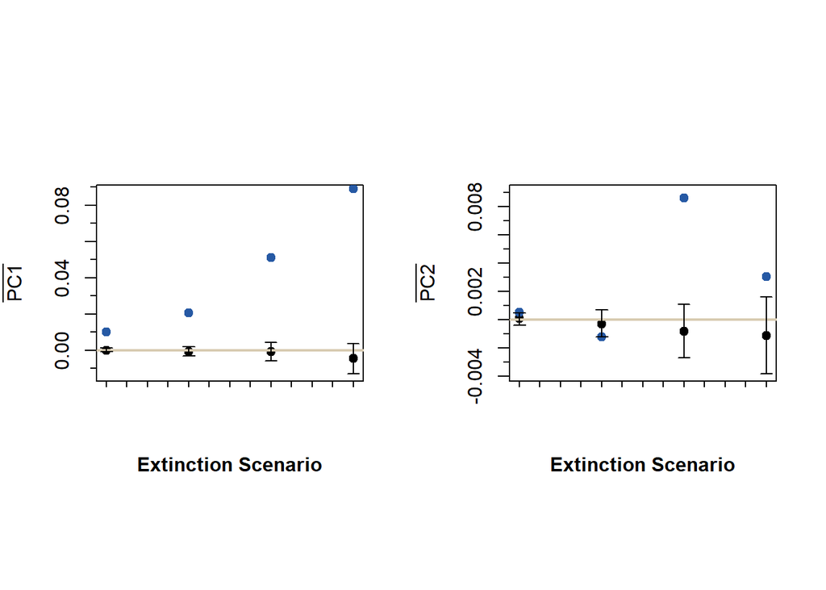

```r
# Extinction levels.
extinction_levels <- c(4,12,22,26)  # CR, (CR + EN), (CR + EN + VU) and (CR + EN + VU + NT)

q <- 100

simulated_spaces <- list()

set.seed(1991)

for(k in extinction_levels) {
  for(i in 1:q) {
    remove_species <- sample(rownames(average_pca$x[,1:2]), k)
    reduced_space <- average_pca$x[,1:2][!rownames(average_pca$x[,1:2]) %in% remove_species, ]

    simulated_spaces[[paste0("remove_", k, "_sim_", i)]] <- reduced_space
  }
}

# Results.
extinction_results <-
  bind_rows(lapply(simulated_spaces, colMeans), .id = "scenario") |>
  mutate(extinction = sub("_sim_.*", "", scenario)) |>
  mutate(extinction = factor(extinction, levels = c("remove_4","remove_12","remove_22","remove_26"))) |>
  as.data.frame()

# Compute summary statistics based on PC1 and PC2.
first_axis <-
  extinction_results |>
  group_by(extinction) |>
  summarise(mean = intervals(Comp1)$mean,
            lwr_ci = intervals(Comp1)$Lower.CI,
            upr_ci = intervals(Comp1)$Upper.CI,
            var = "PC1")

second_axis <-
  extinction_results |>
  group_by(extinction) |>
  summarise(mean = intervals(Comp2)$mean,
            lwr_ci = intervals(Comp2)$Lower.CI,
            upr_ci = intervals(Comp2)$Upper.CI,
            var = "PC2")

# Plot results.
combined_results <- rbind(first_axis,second_axis)

# layout(matrix(c(1,2,3,3),nrow = 2,ncol = 2),
#        widths = c(6,6,7),heights = c(7,7,7),
#        respect = T)

layout(matrix(c(1:2),nrow = 1,ncol = 2),respect = T)

plot(combined_results$mean[1:4],
     ylim = range(c(combined_results$lwr_ci[1:4], 0.08713091)),
     xlab = "Extinction Scenario",
     ylab = expression(bar(PC1)),
     xaxt = "n",
     bg = "white",font.lab = 2,
     pch = 19);minor.tick(nx = 2, ny = 2, tick.ratio = 0.5)

# The observed (i.e. real) changes in mean value along PC1 and PC2 under each extinction scenario.
points(1:4,c(c2[1],c3[1],c4[1],c5[1]),col = "#2659A4", pch = 19)
# Add solid line for reference.
abline(h = mean(average_pca$x[,1]),col = "#d8cbb1",lwd = 2)

# Add error bars
arrows(x0 = 1:4, y0 = combined_results$lwr_ci[1:4],
       x1 = 1:4, y1 = combined_results$upr_ci[1:4],
       angle = 90, code = 3, length = 0.05,lty = 1)

# PC2.
plot(combined_results$mean[5:8],
     ylim = range(c(combined_results$lwr_ci[5:8], 0.009)),
     xlab = "Extinction Scenario",
     ylab = expression(bar(PC2)),font.lab = 2,
     bg = "white",
     xaxt = "n",
     pch = 19);minor.tick(nx = 2, ny = 2, tick.ratio = 0.5)

# The observed changes in mean value for PC2 under each extinction scenario
points(1:4,c(c2[2],c3[2],c4[2],c5[2]),col = "#2659A4", pch = 19)

abline(h = mean(average_pca$x[,2]),col = "#d8cbb1",lwd = 2)

arrows(x0 = 1:4, y0 = combined_results$lwr_ci[5:8],
       x1 = 1:4, y1 = combined_results$upr_ci[5:8],
       angle = 90, code = 3, length = 0.05)
```

## Disparity analysis

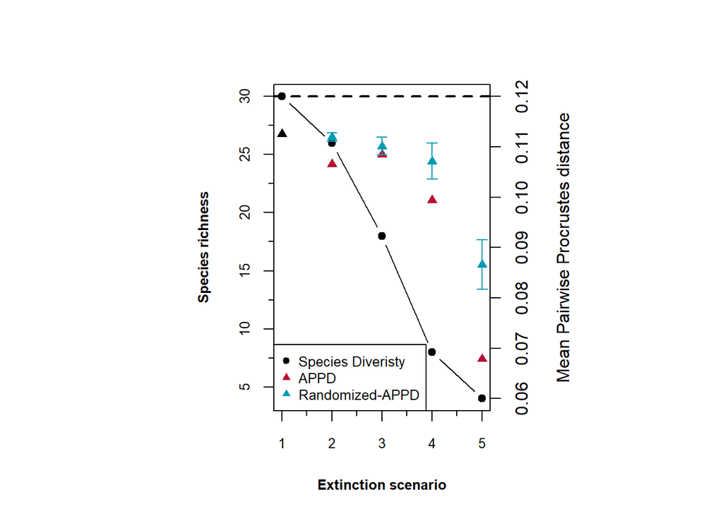

```r
# Plot species richness.
# par(mar = c(5,5,3,5))
layout(matrix(c(1:1),ncol = 1),widths = 2,heights = 3,respect = T)

plot(x = 1:5, y = c(30,26,18,8,4),ylab = "Species richness",
     pch = 19,type = "b",xlab = "Extinction scenario",cex.axis = 0.8,cex.lab = 0.8,
     font.lab = 2);abline(h = 30,lwd = 2,lty = 2);minor.tick(nx = 2, ny = 2, tick.ratio = 0.5)

# Plot pairwise Procrustes distance.
par(new = TRUE)

plot(c(
  mean(as.matrix(dist(two.d.array(A = species_subset)))),
  mean(as.matrix(dist(two.d.array(A = species_subset[,,!dimnames(species_subset)[[3]] %in% cr])))),
  mean(as.matrix(dist(two.d.array(A = species_subset[,,!dimnames(species_subset)[[3]] %in% crEn])))),
  mean(as.matrix(dist(two.d.array(A = species_subset[,,!dimnames(species_subset)[[3]] %in% crEnVu])))),
  mean(as.matrix(dist(two.d.array(A = species_subset[,,!dimnames(species_subset)[[3]] %in% crEnVunT]))))
  ),
  ylim = c(0.06,0.12),
  xlab = "", ylab = "",type = "p",pch = 17, cex = 1,
  col = c("black","#B71234","#B71234","#B71234","#B71234"),
  xaxt = "n", yaxt = "n")

axis(side = 4)
mtext("Mean Pairwise Procrustes distance", side = 4, line = 3)

# Simulate extinction at random.
simulated_disparity <- list()

set.seed(1992)

# Will produce a nested array list (n = 100) with the matrix configuration of sampled species for each subsetted case.
for(k in extinction_levels) {
  level_results <- vector("list", q) # q = number of iterations.
  for(i in 1:q) {
    eS <- sample(dimnames(species_subset)[[3]], k) # sampling without replacement.
    eP <- species_subset[,,!dimnames(species_subset)[[3]] %in% eS]
    level_results[[i]] <- eP
  }
  simulated_disparity[[as.character(k)]] <- level_results
}

# 4 species going extinct at random.
mean_results_1 <- vector(mode = "list")

for(i in seq_along(simulated_disparity[[1]])) {
  # Compute the mean Procrustes distance of each sample.
  tr1 <- mean(as.matrix(dist(two.d.array(A = simulated_disparity[[1]][[i]])))) # First Scenario
  mean_results_1[[i]] <- tr1
  mean_results_1 <- unlist(mean_results_1)
}

# 12 species going extinct at random.
mean_results_2 <- vector(mode = "list")

for(i in seq_along(simulated_disparity[[2]])) {
  tr2 <- mean(as.matrix(dist(two.d.array(A = simulated_disparity[[2]][[i]])))) # Second Scenario
  mean_results_2[[i]] <- tr2
  mean_results_2 <- unlist(mean_results_2)
}

# 22 species going extinct at random.
mean_results_3 <- vector(mode = "list")

for(i in seq_along(simulated_disparity[[3]])) {
  tr3 <- mean(as.matrix(dist(two.d.array(A = simulated_disparity[[3]][[i]])))) # Third Scenario
  mean_results_3[[i]] <- tr3
  mean_results_3 <- unlist(mean_results_3)
}

# 24 species going extinct at random.
mean_results_4 <- vector(mode = "list")

for(i in seq_along(simulated_disparity[[4]])) {
  tr4 <- mean(as.matrix(dist(two.d.array(A = simulated_disparity[[4]][[i]])))) # Fourth Scenario
  mean_results_4[[i]] <- tr4
  mean_results_4 <- unlist(mean_results_4)
}

# Combine results.
APPD <-
  cbind(mean_results_1,mean_results_2,mean_results_3,mean_results_4) |>
  as.data.frame() |>
  setNames(nm = c("remove_4","remove_12","remove_22","remove_26")) |>
  pivot_longer(cols = c(1:4),names_to = "extinction") |>
  # Estimate CI intervals around mean distributions.
  group_by(extinction) |>
  summarise(mean =   intervals(value)$mean,
            lwr_ci = intervals(value)$Lower.CI,
            upr_ci = intervals(value)$Upper.CI
            ) |>
  ungroup() |>
  mutate(extinction = factor(extinction, levels = c("remove_4","remove_12","remove_22","remove_26"))) |>
  # Add dummy row.
  add_row(extinction = "remove_none", mean = NA, lwr_ci = NA, upr_ci = NA)

# par(new = TRUE)
# plot(APPD_res$mean[c(5,4,1:3)],
#      ylim = range(c(APPD_res$lwr_ci, APPD_res$upr_ci),na.rm = T),
#      xlab = "", ylab = "",type = "p",pch = 17, cex = 1,
#      col = "lightblue",
#      xaxt = "n", yaxt = "n")

arrows(
  x0 = 1:5, y0 = APPD$lwr_ci[c(5,4,1:3)],
  x1 = 1:5, y1 = APPD$upr_ci[c(5,4,1:3)],
  angle = 90, code = 3, length = 0.05,col = "#009AB4",
)

points(APPD$mean[c(5,4,1:3)],pch = 17, col = "#009AB4")

# Add legend.
legend("bottomleft",legend = c("Species Diveristy","APPD","Randomized-APPD"),
       col = c("black","#B71234","#009AB4"),
       pch = c(19,17,17),cex = .8)
```

```r
#axis(side = 4, line = 4)
#mtext("Simulated Extinction", side = 4, line = 6)
```

## Sensitivity analyses

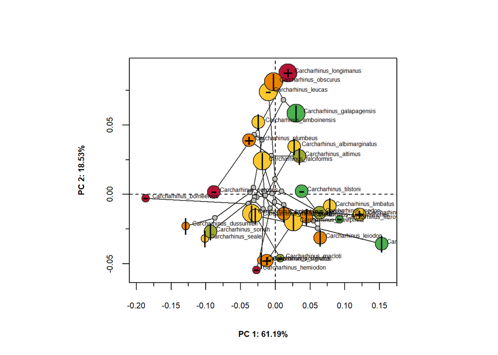

```r
# Species average based on upper and lower teeth.
jaw_coords <- tooth_gpa$coords

dimnames(jaw_coords)[[3]] <- gsub("-"," ",dimnames(jaw_coords)[[3]])         # Remove the dash between genus and species name.
dimnames(jaw_coords)[[3]] <- gsub("_U", "_Upper",dimnames(jaw_coords)[[3]])  # Substitute upper case U and L with Upper and Lower.
dimnames(jaw_coords)[[3]] <- gsub("_L", "_Lower",dimnames(jaw_coords)[[3]])
dimnames(jaw_coords)[[3]] <- gsub("[0-9]+", "", dimnames(jaw_coords)[[3]])   # Remove alphanumerical values.
# Lastly remove anything that contains this text string: _Bass et al _Pl.
dimnames(jaw_coords)[[3]] <- gsub("|_Bass et al _Pl|_Bass et al _Pla", "", dimnames(jaw_coords)[[3]])

# Computing an average shape.
jaw_subset <- coords.subset(A = jaw_coords, group = as.factor(dimnames(jaw_coords)[[3]]))

jaw_subset <-
  lapply(jaw_subset, mshape) |>
  simplify2array()

# dim(jaw_subset) # 60 configurations.

# Final pre-processing.
upper_jaw_coords <- jaw_subset[,,grep(pattern = "Upper",x = dimnames(jaw_subset)[[3]],value = T)]
lower_jaw_coords <- jaw_subset[,,grep(pattern = "Lower",x = dimnames(jaw_subset)[[3]],value = T)]

dimnames(upper_jaw_coords)[[3]] <- gsub("_.*","",x = dimnames(upper_jaw_coords)[[3]])
dimnames(upper_jaw_coords)[[3]] <- gsub(" ","_", x = dimnames(upper_jaw_coords)[[3]])

dimnames(lower_jaw_coords)[[3]] <- gsub("_.*","",x = dimnames(lower_jaw_coords)[[3]])
dimnames(lower_jaw_coords)[[3]] <- gsub(" ","_", x = dimnames(lower_jaw_coords)[[3]])

# PCA.
average_upper_jaw <- gm.prcomp(A = upper_jaw_coords,phy = carcharhinus_tree)
average_lower_jaw <- gm.prcomp(A = lower_jaw_coords,phy = carcharhinus_tree)

# Serration type for upper teeth by species.
upper_serrations_frame <-
  Data |>
  filter(Jaw == "Upper") |>
  select(Species,Serration) |>
  distinct(Species,.keep_all = T) |>
  mutate(Species = gsub(" ","_",Species)) |>
  mutate(Serration = stringr::str_squish(Serration)) |>
  as_tibble()

lower_serrations_frame <-
  Data |>
  filter(Jaw == "Lower") |>
  select(Species,Serration) |>
  distinct(Species,.keep_all = T) |>
  mutate(Species = gsub(" ","_",Species)) |>
  mutate(Serration = stringr::str_squish(Serration)) |>
  as_tibble()

# Plot upper dental configurations.
layout(matrix(c(1:1)),respect = T)
plot(average_upper_jaw, axis1 = 1, axis2 = 2,phylo = TRUE, main = NULL,
     cex = setNames(c(3.5,2.5,1.5),levels(size_species))[size_species[rownames(average_upper_jaw$x)]],
     pch = 21,asp = 2,col = "#2E2D29",
     bg = iucn_colours[iucn_species[rownames(average_upper_jaw$x)]],font.lab = 2,cex.axis = .7,cex.lab = .7,
     phylo.par= list(tip.labels = T, node.labels=FALSE, edge.color= "#2E2D29",
                     edge.width= 1, tip.txt.cex =0.5,
                     tip.txt.adj = c(-0.1, -0.1))
     ); minor.tick(nx = 2, ny = 2, tick.ratio = 0.5)

par(new = T)
points(average_upper_jaw$x[,1:2], pch = as.vector(unname(habitat_symbol[rownames(average_upper_jaw$x)])), col = "black", cex = 1.5)
```

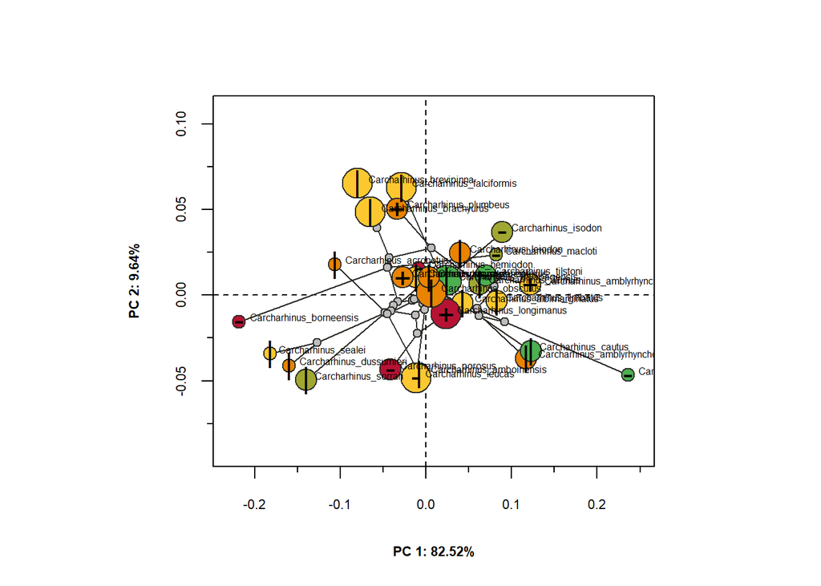

```r
plot(average_lower_jaw, axis1 = 1, axis2 = 2,phylo = TRUE, main = NULL,
     # Serrations.
     # lwd =c(4,2,1,.5)[as.factor(setNames(lower_serrations_frame$Serration,lower_serrations_frame$Species))],
     # Body size.
     cex = setNames(c(3.5,2.5,1.5),levels(size_species))[size_species[rownames(average_pca$x)]],
     pch = 21,asp = 2,col = "#2E2D29",
     # IUCN status.
     bg = iucn_colours[iucn_species[rownames(average_pca$x)]],font.lab = 2,cex.axis = .7,cex.lab = .7,
     phylo.par= list(tip.labels = T, node.labels=FALSE, edge.color= "#2E2D29",
                     edge.width= 1, tip.txt.cex =0.5,
                     tip.txt.adj = c(-0.1, -0.1))
     ); minor.tick(nx = 2, ny = 2, tick.ratio = 0.5)

par(new = T)
points(average_lower_jaw$x[,1:2], pch = as.vector(unname(habitat_symbol[rownames(average_lower_jaw$x)])), col = "black", cex = 1.5)
```

```r
dev.off()
```

```r
par(mfrow = c(1,2))
plotRefToTarget(average_upper_jaw$shapes$shapes.comp1$min,average_upper_jaw$shapes$shapes.comp1$min)
plotRefToTarget(average_upper_jaw$shapes$shapes.comp1$max,average_upper_jaw$shapes$shapes.comp1$max)
plotRefToTarget(average_upper_jaw$shapes$shapes.comp2$min,average_upper_jaw$shapes$shapes.comp2$min)
plotRefToTarget(average_upper_jaw$shapes$shapes.comp2$max,average_upper_jaw$shapes$shapes.comp2$max)
#
plotRefToTarget(average_lower_jaw$shapes$shapes.comp1$min,average_lower_jaw$shapes$shapes.comp1$min)
plotRefToTarget(average_lower_jaw$shapes$shapes.comp1$max,average_lower_jaw$shapes$shapes.comp1$max)
plotRefToTarget(average_lower_jaw$shapes$shapes.comp2$min,average_lower_jaw$shapes$shapes.comp2$min)
plotRefToTarget(average_lower_jaw$shapes$shapes.comp2$max,average_lower_jaw$shapes$shapes.comp2$max)
# dev.off()

# ANOVA.
gdf_sensitivity <-
  geomorph.data.frame(
    upper_coords = upper_jaw_coords,
    lower_coords = lower_jaw_coords,
    status =
      dimnames(upper_jaw_coords)[[3]] |>
      as.data.frame() |> setNames(nm = "Species") |>
      left_join(Traits |> select(Genus,Species,IUCN) |> mutate(Species = paste0(Genus,"_",Species)),by = "Species") |>
      select(-2) |>
      pull(IUCN)
    )

fit_09 <- procD.lm(f1 = upper_coords ~ status,RRPP = T,data = gdf_sensitivity, iter = 999)
anova(fit_09)
```

```
Analysis of Variance, using Residual Randomization
Permutation procedure: Randomization of null model residuals
Number of permutations: 1000
Estimation method: Ordinary Least Squares
Sums of Squares and Cross-products: Type I
Effect sizes (Z) based on F distributions

          Df       SS        MS     Rsq     F      Z Pr(>F)
status     4 0.056299 0.0140747 0.22601 1.825 1.4702  0.061 .
Residuals 25 0.192802 0.0077121 0.77399
Total     29 0.249101
---
Signif. codes:  0 '***' 0.001 '**' 0.01 '*' 0.05 '.' 0.1 ' ' 1

Call: procD.lm(f1 = upper_coords ~ status, iter = 999, RRPP = T, data = gdf_sensitivity)
```

```r
fit_10 <- procD.lm(f1 = lower_coords ~ status,RRPP = T,data = gdf_sensitivity, iter = 999)
anova(fit_10)
```

```
Analysis of Variance, using Residual Randomization
Permutation procedure: Randomization of null model residuals
Number of permutations: 1000
Estimation method: Ordinary Least Squares
Sums of Squares and Cross-products: Type I
Effect sizes (Z) based on F distributions

          Df      SS       MS     Rsq      F     Z Pr(>F)
status     4 0.07959 0.019897 0.22897 1.8561 1.245    0.1
Residuals 25 0.26800 0.010720 0.77103
Total     29 0.34759

Call: procD.lm(f1 = lower_coords ~ status, iter = 999, RRPP = T, data = gdf_sensitivity)
```

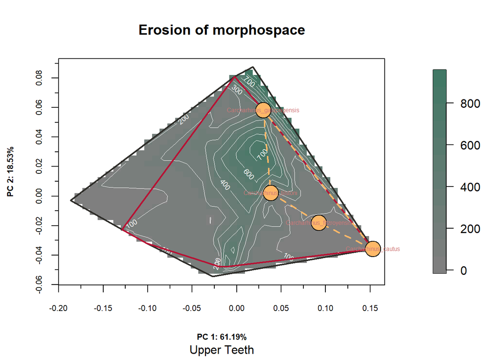

```r
# Upper tooth configurations.
hull.5 <- grDevices::chull(average_upper_jaw$x[,1:2]) # Full dental morphospace.
hull.6 <- grDevices::chull(average_upper_jaw$x[!rownames(average_upper_jaw$x) %in% cr,1:2])
hull.7 <- grDevices::chull(average_upper_jaw$x[!rownames(average_upper_jaw$x) %in% crEn,1:2])
hull.8 <- grDevices::chull(average_upper_jaw$x[!rownames(average_upper_jaw$x) %in% crEnVu,1:2])
hull.9 <- grDevices::chull(average_upper_jaw$x[!rownames(average_upper_jaw$x) %in% crEnVunT,1:2])

# PC1 vs PC2 vs Depth
depth_akima_upper <- interp(average_upper_jaw$x[,1], average_upper_jaw$x[,2],
                            setNames(Traits$Depth,paste(Traits$Genus,Traits$Species, sep = "_"))[rownames(average_upper_jaw$x)],
                            linear = T, extrap = F) # Smooth raster grid mappigng depths onto the shape space.

# Plot.
par(mar=c(5.1, 4.1, 4.1, 8.1), xpd=TRUE)

plot(average_upper_jaw$x[,1:2],
     type = "n", main = "Erosion of morphospace",sub = "Upper Teeth",
     xlim = c(-0.1865064,0.1530878),
     ylim = c(-0.05455346,0.08755696),
     xlab = "PC 1: 61.19%", ylab = "PC 2: 18.53%",
     font.lab = 2,cex.axis = .7,cex.lab = .7,);minor.tick(nx = 2, ny = 2, tick.ratio = 0.5)

# Depth profile.
image(depth_akima_upper, add=TRUE,col = colorRampPalette(c("#7f7f7f", "#417865"))(12))
contour(depth_akima_upper, add=TRUE,method = "edge",lwd = .5, col = "white")

# Legend.
image.plot(depth_akima_upper, col = colorRampPalette(c("#7f7f7f", "#417865"))(12),legend.only = T)

# Ranges (minimum convex hulls)
polygon(average_upper_jaw$x[,1:2][hull.5,],lty = 1,border = "#2E2D29",lwd = 2) # Full morphospace.
polygon(average_upper_jaw$x[!rownames(average_pca$x) %in% cr,1:2][hull.6,],
        lty = 1,border = "#B71234",lwd = 2) # CR eliminated.

# Additive extinctions.
# polygon(average_upper_jaw$x[!rownames(average_pca$x) %in% crEn,1:2][hull.7,],
#         lty = 1,border = "#2E2D29",lwd = 2) # CR and EN eliminated

# polygon(average_upper_jaw$x[!rownames(average_pca$x) %in% crEnVu,1:2][hull.8,],
#         lty = 1,border = "#2E2D29",lwd = 2) # CR,EN, and VU eliminated

polygon(average_upper_jaw$x[!rownames(average_pca$x) %in% crEnVunT,1:2][hull.9,],
        lty = 2,border = "#FEB868",lwd = 2) # CR,EN, VU, and NT eliminated

points(average_upper_jaw$x[!rownames(average_pca$x) %in% crEnVunT,1:2], bg = "#FEB868",pch = 21, cex = 3)
text(x = average_upper_jaw$x[!rownames(average_pca$x) %in% crEnVunT,1],
     y = average_upper_jaw$x[!rownames(average_pca$x) %in% crEnVunT,2],
     labels = names(average_upper_jaw$x[!rownames(average_pca$x) %in% crEnVunT,1]),
     col = "#CF7878", cex = .5, font.lab = 2)
```

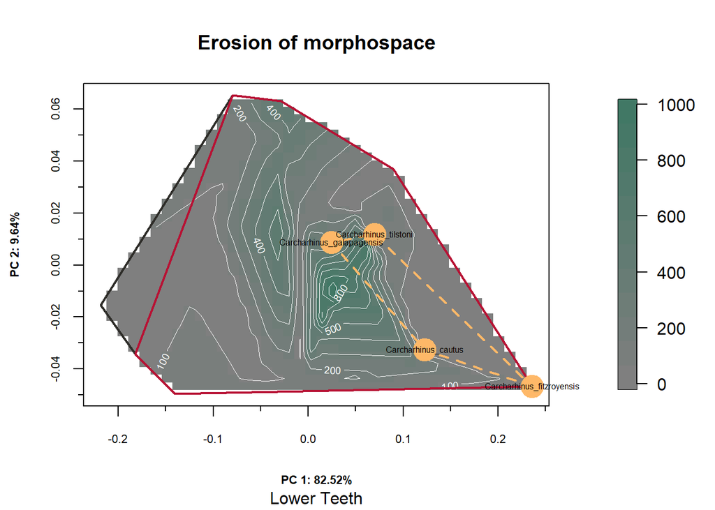

```r
# Lower tooth configurations.
hull.10 <- grDevices::chull(average_lower_jaw$x[,1:2]) # Full dental morphospace.
hull.11 <- grDevices::chull(average_lower_jaw$x[!rownames(average_lower_jaw$x) %in% cr,1:2])
hull.12 <- grDevices::chull(average_lower_jaw$x[!rownames(average_lower_jaw$x) %in% crEn,1:2])
hull.13 <- grDevices::chull(average_lower_jaw$x[!rownames(average_lower_jaw$x) %in% crEnVu,1:2])
hull.14 <- grDevices::chull(average_lower_jaw$x[!rownames(average_lower_jaw$x) %in% crEnVunT,1:2])

# PC1 vs PC2 vs Depth.
depth_akima_lower <- interp(average_lower_jaw$x[,1], average_lower_jaw$x[,2],
                            setNames(Traits$Depth,paste(Traits$Genus,Traits$Species, sep = "_"))[rownames(average_lower_jaw$x)],
                            linear = T, extrap = F)

# Plot.
par(mar=c(5.1, 4.1, 4.1, 8.1), xpd=TRUE)

plot(average_lower_jaw$x[,1:2],
     type = "n", main = "Erosion of morphospace",sub = "Lower Teeth",
     xlim = c(-0.2184150,0.2357515),
     ylim = c(-0.04958307,0.06523407),
     xlab = "PC 1: 82.52%", ylab = "PC 2: 9.64%",
     font.lab = 2,cex.axis = .7,cex.lab = .7,);minor.tick(nx = 2, ny = 2, tick.ratio = 0.5)

# Depth profile.
image(depth_akima_lower, add=TRUE,col = colorRampPalette(c("#7f7f7f", "#417865"))(12))
contour(depth_akima_lower, add=TRUE,method = "edge",lwd = .5, col = "white")

# Legend.
image.plot(depth_akima_lower, col = colorRampPalette(c("#7f7f7f", "#417865"))(12),legend.only = T)

# Ranges (minimum convex hulls)
polygon(average_lower_jaw$x[,1:2][hull.10,],lty = 1,border = "#2E2D29",lwd = 2) # Full morphospace.
polygon(average_lower_jaw$x[!rownames(average_pca$x) %in% cr,1:2][hull.11,],
        lty = 1,border = "#B71234",lwd = 2) # CR eliminated.

# Additive extinctions.
# polygon(average_upper_jaw$x[!rownames(average_pca$x) %in% crEn,1:2][hull.7,],
#         lty = 1,border = "#2E2D29",lwd = 2) # CR and EN eliminated

# polygon(average_upper_jaw$x[!rownames(average_pca$x) %in% crEnVu,1:2][hull.8,],
#         lty = 1,border = "#2E2D29",lwd = 2) # CR,EN, and VU eliminated

polygon(average_lower_jaw$x[!rownames(average_pca$x) %in% crEnVunT,1:2][hull.14,],
        lty = 2,border = "#FEB868",lwd = 2) # CR,EN, VU, and NT eliminated.


points(average_lower_jaw$x[!rownames(average_pca$x) %in% crEnVunT,1:2], col = "#FEB868",pch = 19, cex = 3)
text(x = average_lower_jaw$x[!rownames(average_lower_jaw$x) %in% crEnVunT,1],
     y = average_lower_jaw$x[!rownames(average_lower_jaw$x) %in% crEnVunT,2],
     labels = names(average_lower_jaw$x[!rownames(average_lower_jaw$x) %in% crEnVunT,1]),
     col = "black", cex = .5, font.lab = 2)
```

## Procrustes variance

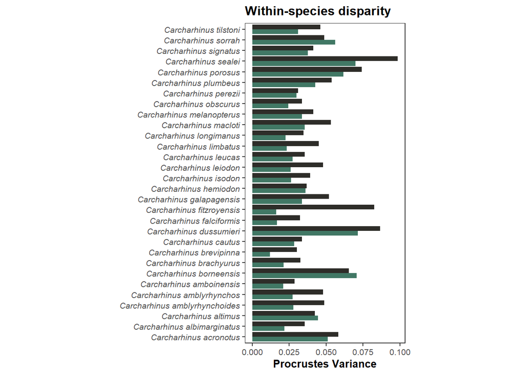

```r
# Within-group disparity.
within_grp_PV <- morphol.disparity(f1 = coords ~ 1,groups = ~ species,iter = 999,data = gdf_specimens,print.progress = F)

pv_01 <- within_grp_PV$Procrustes.var |>
  as.data.frame() |>
  setNames(nm = "PV") |>
  rownames_to_column(var = "Species") |>
  mutate(Species = gsub("-"," ", Species)) |>
  left_join(y = Traits |> select(Genus,Species,IUCN,Size_Subclass,Sorensen_habitat) |> mutate(Species = paste0(Genus," ",Species)),by = "Species") |>
  select(-3)

# summary(aov(formula = pv_01$PV ~ pv_01$Size_Subclass))    # Signifiacnt.
# summary(aov(formula = pv_01$PV ~ pv_01$Sorensen_habitat)) # Not Signifiacnt.
# summary(aov(formula = pv_01$PV ~ pv_01$IUCN))             # Not Signifiacnt.

# TukeyHSD(x = aov(formula = pv_01$PV ~ pv_01$Size_Subclass))

# Disparity within species and jaws.
within_dignathic_PV <- morphol.disparity(f1 = coords ~ 1,groups = ~ species+dignathic_heterodonty,iter = 999,data = gdf_specimens,print.progress = F)

p17  <-
  within_dignathic_PV$Procrustes.var |>
  as.data.frame() |>
  setNames(nm = "PV") |>
  rownames_to_column(var = "Species") |>
  mutate(Jaw = Species,
         Jaw = sub("^[^.]*\\.", "", Jaw),
         Jaw = as.factor(Jaw)) |>
  mutate(Jaw = case_when(Jaw == "U" ~ "Upper",
                         Jaw == "L" ~ "Lower", T ~ Jaw)) |>
  mutate(Jaw = factor(Jaw, levels = c("Upper","Lower"))) |>
  mutate(Species = gsub("-"," ",Species)) |>
  mutate(Species = gsub(".U|.L","",Species)) |>
  left_join(y = Traits |> select(Genus,Species,IUCN,Size_Subclass,Sorensen_habitat) |> mutate(Species = paste0(Genus," ",Species)),by = "Species") |>
  # Plot.
  ggplot(mapping = aes(x = PV, y = Species, fill = Jaw)) +
  geom_bar(stat = "identity",position = "dodge") +
  scale_fill_manual(values =  c("#417865","#2E2D29")) +
  scale_color_manual(values = c("#417865","#2E2D29")) +
  # Labels.
  labs(x = "Procrustes Variance", y = NULL, title = "Within-species disparity") +
  theme_bw() +
  theme(aspect.ratio = 2,
        panel.grid = element_blank(),
        axis.title = element_text(face = "bold",size = 10),
        legend.position = "none",
        legend.title = element_text(face = "bold"),
        plot.title = element_text(face = "bold",size = 12),
        axis.text = element_text(size = 8),
        axis.text.y = element_text(face = "italic"))

p17 |> print()
```

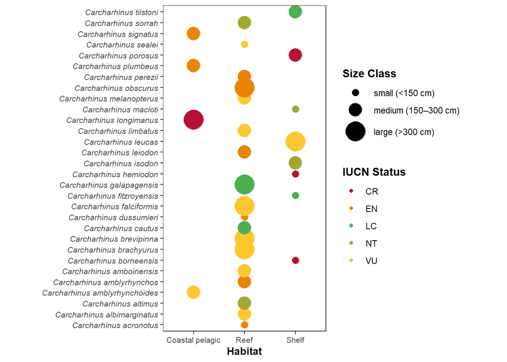

```r
p18 <-
  pv_01 |>
  select(c(1,3:5)) |>
  mutate(Size_Subclass = gsub("_shark","",Size_Subclass)) |>
  mutate(Size_Subclass = case_when(Size_Subclass == "small" ~ "small (<150 cm)",
                                   Size_Subclass == "medium" ~ "medium (150–300 cm)",
                                   Size_Subclass == "large" ~ "large (>300 cm)", T  ~ Size_Subclass)) |>
  mutate(Size_Subclass = factor(Size_Subclass, levels = c("small (<150 cm)","medium (150–300 cm)","large (>300 cm)"))) |>
  ggplot(aes(x = Sorensen_habitat, y = Species)) +
  geom_point(aes(size = Size_Subclass, color = IUCN)) +
  scale_size_manual(values = c(3,6,9)) +
  scale_color_manual(values = c("LC"="#4CAF50","NT"="#A0A831","VU"="#FDC82F","EN"="#E98300","CR"="#B71234")) +
  labs(x = "Habitat", y = NULL,size = "Size Class",color = "IUCN Status") +
  theme_bw() +
  theme(aspect.ratio = 2,
        panel.grid = element_blank(),
        axis.title = element_text(face = "bold",size = 10),
        legend.position = "right",
        legend.title = element_text(face = "bold"),
        plot.title = element_text(face = "bold",size = 12),
        axis.text = element_text(size = 8),
        axis.text.y = element_text(face = "italic"))

p18 |> print()
```

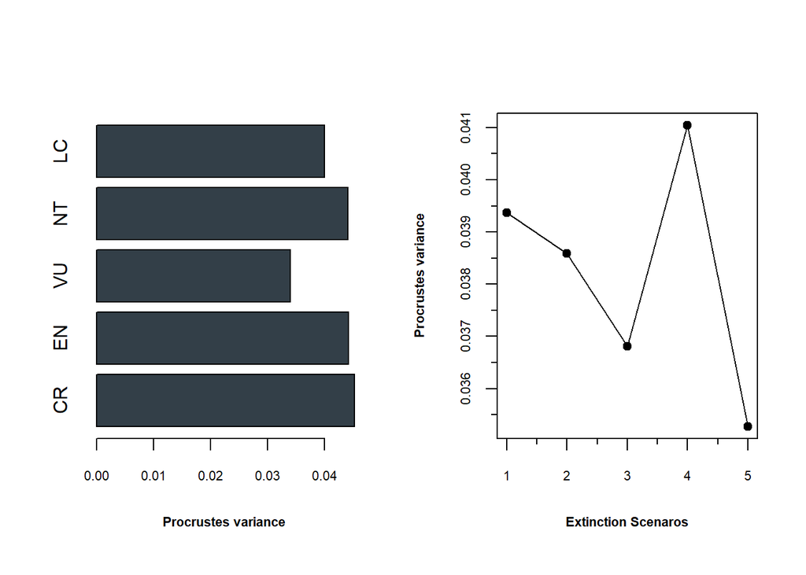

```r
# Overall mean.
pv_iucn <- morphol.disparity(f1 = coords ~ 1,groups = ~ iucn,iter = 999,data = gdf_specimens)
# Plot.
layout(matrix(c(1:2),ncol = 2,byrow = T),widths = c(3,3),heights = c(4,4),respect = T)

pv_iucn$Procrustes.var[c(1:2,5,4,3)] |>
  barplot(col = "#333F48FF",horiz = T,xlab = "Procrustes variance",font.lab = 2,cex.axis = .7,cex.lab = .7)

# pv_iucn$PV.dist.Pval

mdp.1 = tooth_gpa$coords[,,setdiff(dimnames(tooth_gpa$coords)[[3]],rownames(Data[Data$Species %in% gsub("_"," ",cr),]))]      # Excludes CR.
mdp.2 = tooth_gpa$coords[,,setdiff(dimnames(tooth_gpa$coords)[[3]],rownames(Data[Data$Species %in% gsub("_"," ",crEn),]))]    # Excludes CR % EN
mdp.3 = tooth_gpa$coords[,,setdiff(dimnames(tooth_gpa$coords)[[3]],rownames(Data[Data$Species %in% gsub("_"," ",crEnVu),]))]  # Excludes CR % EN & VU
mdp.4 = tooth_gpa$coords[,,setdiff(dimnames(tooth_gpa$coords)[[3]],rownames(Data[Data$Species %in% gsub("_"," ",crEnVunT),]))] # Excludes CR % EN & VU & NT.

morphol.disparity(f1 = coords ~ 1,groups = NULL,iter = 999,data = gdf_specimens,print.progress = F) # Baseline.
morphol.disparity(f1 = mdp.1 ~ 1,groups = NULL,iter = 999,print.progress = F)
morphol.disparity(f1 = mdp.2 ~ 1,groups = NULL,iter = 999,print.progress = F)
morphol.disparity(f1 = mdp.3 ~ 1,groups = NULL,iter = 999,print.progress = F)
morphol.disparity(f1 = mdp.4 ~ 1,groups = NULL,iter = 999,print.progress = F)

plot(x = c(1:5), y = c(0.03936576,0.03858905,0.03680784,0.04104313,0.03527784),
     type = "o",
     xlab = "Extinction Scenaros",
     ylab = "Procrustes variance",
     pch = 19,
     font.lab = 2,
     cex.axis = .7,
     cex.lab = .7);minor.tick(nx = 2, ny = 2, tick.ratio = 0.5)
```

## Phylogenetic signal

```r
# Test for phylogenetic signal in tooth shape.
carcharhinus_signal <- geomorph::physignal(A = species_subset,phy = carcharhinus_tree,iter = 999,seed = 1,print.progress = F)
# Any difference between upper and lower teeth?
upper_signal <- geomorph::physignal(A = upper_jaw_coords,phy = carcharhinus_tree,iter = 999,seed = 1,print.progress = F)
lower_signal <- geomorph::physignal(A = lower_jaw_coords,phy = carcharhinus_tree,iter = 999,seed = 1,print.progress = F)

# Effect size.
carcharhinus_effect <- geomorph::physignal.z(A = species_subset,phy = carcharhinus_tree)
upper_effect <- geomorph::physignal.z(A = upper_jaw_coords,phy = carcharhinus_tree)
lower_effect <- geomorph::physignal.z(A = lower_jaw_coords,phy = carcharhinus_tree)

# Compare the signal across all three sets.
ps_list <- list(carcharhinus_effect, upper_effect,lower_effect); names(ps_list) <- c("combined", "upper","lower")
# summary(compare.physignal.z(ps_list))
```

## Ecological diversity

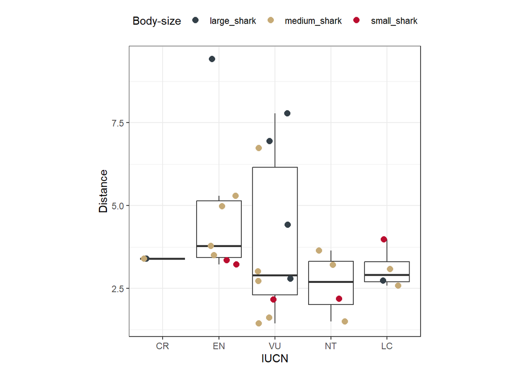

```r
d1 <- vegdist(x = as.matrix(unclass(clr(acomp(closed_diets)))[,1:10]), method = "euclidean") # All.
# Re-calculate after elimination of CR, EN, VU, and NT.
d2 <- vegdist(x = as.matrix(unclass(clr(acomp(closed_diets[!rownames(closed_diets) %in% cr,])))[,1:10]), method = "euclidean") # CR
d3 <- vegdist(x = as.matrix(unclass(clr(acomp(closed_diets[!rownames(closed_diets) %in% crEn,])))[,1:10]), method = "euclidean") # CR + EN
d4 <- vegdist(x = as.matrix(unclass(clr(acomp(closed_diets[!rownames(closed_diets) %in% crEnVu,])))[,1:10]), method = "euclidean") # CR + EN + VU
d5 <- vegdist(x = as.matrix(unclass(clr(acomp(closed_diets[!rownames(closed_diets) %in% crEnVunT,])))[,1:10]), method = "euclidean") # CR + EN + VU + NT

# Multivariate homogeneity of groups dispersion.
bd0 <- betadisper(d1, group = Diets$IUCN_2024)

ex0 <- betadisper(d1, group = as.factor(rep("A",27)))
ex1 <- betadisper(d2, group = as.factor(rep("A",25)))
ex2 <- betadisper(d3, group = as.factor(rep("A",18)))
ex3 <- betadisper(d4, group = as.factor(rep("A",8)))
ex4 <- betadisper(d5, group = as.factor(rep("A",4)))

bd0$distances |>
  as.data.frame() |>
  setNames(nm = "Distance") |>
  rownames_to_column(var = "Species") |>
  left_join(Traits |> select(Genus, Species, IUCN,Size_Subclass) |> mutate(Species = paste(Genus,Species,sep = "_")),by = "Species") |>
  mutate(IUCN = factor(IUCN, levels = c("CR","EN","VU","NT","LC"))) |>
  mutate("Body-size" = Size_Subclass) |>
  as_tibble() |>
  ggplot(mapping = aes(x = IUCN, y = Distance)) +
  geom_boxplot(outlier.shape = NA, width=.8) +
  geom_jitter(aes(colour = `Body-size`),size = 2.5) +
  scale_fill_manual(values =    c("#333F48FF","#C6AA76FF","#BA0C2FFF")) +
  scale_colour_manual(values =  c("#333F48FF","#C6AA76FF","#BA0C2FFF")) +
  theme_bw() +
  theme(legend.position = "top",aspect.ratio = 1) # measuring directional change in ecological space.
```

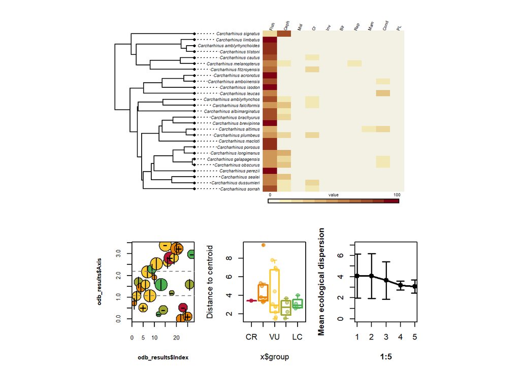

```r
# Plot diet results.
layout(matrix(c(1,1,1,2,3,4), nrow = 2, byrow = TRUE),
       widths = c(3,3,3),
       heights = c(6,4),
       respect = TRUE)

par(mar = c(2,4,4,2))
phylo.heatmap(tree = tree_diets, X = Diets[,6:15], standardize = F,
              colors = rev(sequential_hcl(11,palette = "Red-Yellow")),split=c(0.6,0.4),
              fsize = .5) # Overwheling fish-eaters across the board.

# ODB.
par(mar = c(5, 4, 2, 1))
plot(x = odb_results$Index,y = odb_results$Axis,
     cex = setNames(c(3.5,2.5,1.5),levels(size_species))[size_species[odb_results$Species]],
     pch = 21,col = "#2E2D29",
     bg = c("#B71234","#E98300","#FDC82F","#A0A831","#4CAF50")[iucn_categories],
     font.lab = 2,cex.axis = .7,cex.lab = .7)

par(new = T)
points(x = odb_results$Index,y = odb_results$Axis, pch = as.vector(unname(habitat_symbol[odb_results$Species])),
       col = "black", cex = 1.5)
# Add quantiles.
abline(h = c(quantile(odb_results$Axis, c(0.33, 0.66))),col = "grey50", lty = 2) # or 0.025 and 0.975

# text(x = odb_results$Index,y = odb_results$Axis,labels = odb_results$Species,cex = .5)

boxplot(bd0, col = "white",border = c("#B71234","#E98300","#FDC82F","#A0A831","#4CAF50"),
        boxwex=.8,staplewex=.5,boxlwd=2,medlwd=2)

points(jitter(as.numeric(bd0$group)), bd0$distances,
       col = scales::alpha(c("#B71234","#E98300","#FDC82F","#A0A831","#4CAF50"),.5)[bd0$group],
       pch = 19)

# bd0$distances |>
#   as.data.frame() |>
#   setNames(nm = "value") |>
#   rownames_to_column(var = "Species") |>
#   left_join(Traits |> select(Genus,Species, IUCN) |> mutate(Species = paste(Genus,Species,sep = "_")), by = "Species") |>
#   filter(IUCN == "VU") |>
#   arrange(desc(value))

mean_dispersion <-
  c(mean(ex0$distances),
    mean(ex1$distances),
    mean(ex2$distances),
    mean(ex3$distances),
    mean(ex4$distances)
    )

# Plot.
plot(x = 1:5,y = mean_dispersion,type = "o",lwd = 2,ylim = c(0,7),
     pch = 19, ylab = "Mean ecological dispersion",
     font.lab = 2)

grp_sd <- c(
  sd(ex0$distances),
  sd(ex1$distances),
  sd(ex2$distances),
  sd(ex3$distances),
  sd(ex4$distances)
)

arrows(
  x0 = 1:5, y0 = mean_dispersion - grp_sd,
  x1 = 1:5, y1 = mean_dispersion + grp_sd,
  angle = 90, code = 3, length = 0.05, lwd = 1.5
)
```

```r
# Is there a relationship between IUCN status and ODB values?
# summary(aov(odb_results$Axis ~ odb_results$IUCN)) # No.
# summary(aov(odb_results$Axis ~ odb_results$Sorensen_habitat)) # Habitat, no.
# summary(aov(odb_results$Axis ~ odb_results$Size_Subclass)) # Body size, yes. Which one? Large versus small sharks have difference values.

# TukeyHSD(aov(odb_results$Axis ~ odb_results$Size_Subclass), conf.level=.95)

# PERMANOVA.
# adonis2(dist(bd0$distances) ~ bd0$group)
```

## Morphology versus ODB

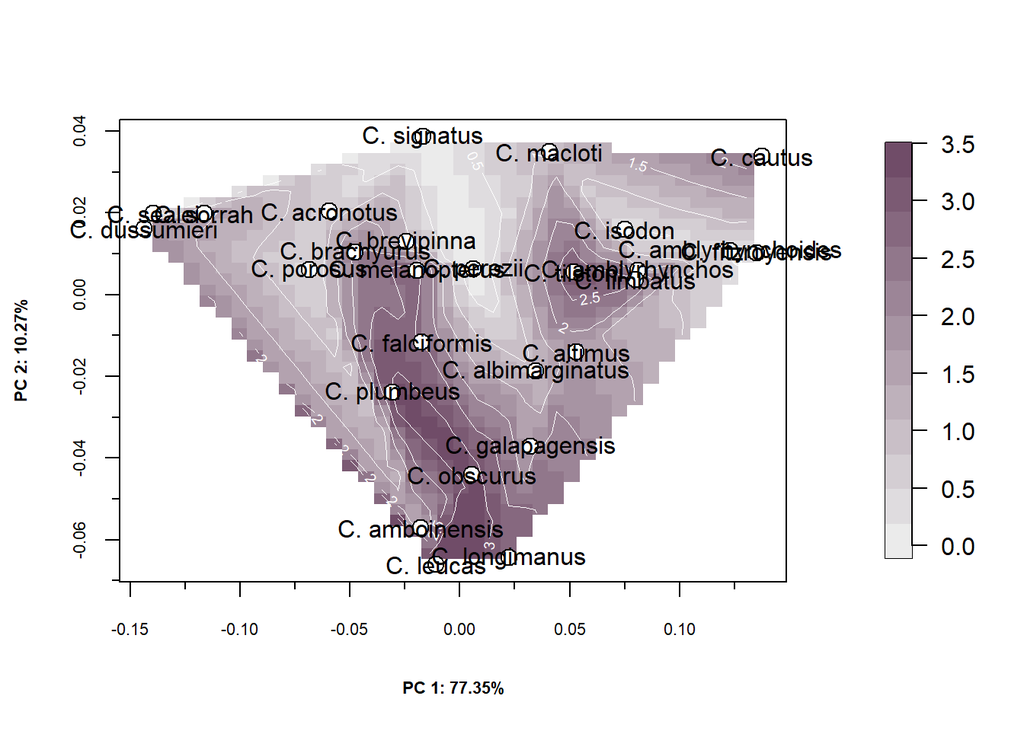

```r
# Relationship between shape and ODB.
# summary(lm(average_pca$x[odb_results$Species,1] ~ odb_results$Axis)) # No.
# summary(lm(average_pca$x[odb_results$Species,2] ~ odb_results$Axis)) # Yes. Inverse relationship.

# Upper teeth
# summary(lm(average_upper_jaw$x[odb_results$Species,1] ~ odb_results$Axis)) # No.
# summary(lm(average_upper_jaw$x[odb_results$Species,2] ~ odb_results$Axis)) # Yes. Inverse relationship.

# Lower teeth
# summary(lm(average_lower_jaw$x[odb_results$Species,1] ~ odb_results$Axis)) # No.
# summary(lm(average_lower_jaw$x[odb_results$Species,2] ~ odb_results$Axis)) # No.

# PC1 vs PC2 vs ODB.
odb_akima <- interp(average_pca$x[odb_results$Species,1],
                    average_pca$x[odb_results$Species,2],
                    odb_results$Axis,
                    linear = T,
                    extrap = F)
# Plot.
par(mar=c(5.1, 4.1, 4.1, 8.1), xpd=TRUE)
# layout(matrix(c(1:1)),respect = T)

plot(average_pca$x[odb_results$Species,1:2],
     type = "n",
     xlim = c(-0.1435757,0.1375744),
     ylim = c(-0.06607903,0.03859228),
     xlab = "PC 1: 77.35%", ylab = "PC 2: 10.27%",
     font.lab = 2,cex.axis = .7,cex.lab = .7,);minor.tick(nx = 2, ny = 2, tick.ratio = 0.5)

# Depth profile.
image(odb_akima, add=TRUE,col = colorRampPalette(c("#EBEBEB", "#704C68"))(12))
contour(odb_akima, add=TRUE,method = "edge",lwd = .5, col = "white")
# Legend.
image.plot(odb_akima,col = colorRampPalette(c("#EBEBEB", "#704C68"))(12),legend.only = T)
# Show species.
points(average_pca$x[odb_results$Species,1:2],
       pch = 21,
       col = "black",bg = "white",
       cex = 1.5)

text(x = average_pca$x[odb_results$Species,1],
     y = average_pca$x[odb_results$Species,2],
     labels = gsub("Carcharhinus","C.",x =  gsub("_"," ",names(average_pca$x[odb_results$Species,1]))),
     col = "black", cex = 1, offset = 2,
     font.lab = 2)
```

## Download data

**Data statement**

The compositional diet data of *Carcharhinus* species analysed herein was compiled by E. Cortes. Future use of this dataset should credit the original source (see Reference list). Conversely, our trait dataset combines information from mulitple sources, including the primary literature and the IUCN Red List database. The original sources should be cited where appropriate.

## References

Cortes, E. 1999. “Standardized Diet Compositions and Trophic Levels of Sharks.” *ICES Journal of Marine Science* 56 (5): 707–17.

Fordyce, C. C. Hamm, J. A. Nice, and M. L. Forister. 2016. “Quantifying Diet Breadth Through Ordination of Host Association. Ecology.” *Ecology* 97 (4): 842–49.